# Change In Single People’s Attachment And Co-Development With Life Satisfaction

###### 6.2.1.7.1.6 Anxiety: Global

Full model results for anxiety (global) (in the consistently single people):

```r
broom::tidy(get(paste0("fit_rq2_", outcomes$short[6], "_24m")), conf.int = TRUE, conf.level = 0.95) %>%
  filter(label != "") %>%
  arrange(label) %>%
  select(term = label, est = estimate, ci_lo = conf.low, ci_hi = conf.high, p_value = p.value, est_std = std.all) %>%
  knitr::kable(digits = 3)
```

| term | est | ci_lo | ci_hi | p_value | est_std |
| --- | --- | --- | --- | --- | --- |
| a0 | 3.432 | 3.355 | 3.509 | 0.000 | 3.744 |
| a1 | -0.777 | -0.880 | -0.674 | 0.000 | -0.849 |
| bi | -0.002 | -0.071 | 0.067 | 0.946 | -0.003 |
| bs | -0.044 | -0.134 | 0.047 | 0.346 | -0.053 |
| cis | -0.123 | -0.226 | -0.020 | 0.019 | -0.147 |
| pred_t00 | 3.432 | 3.355 | 3.509 | 0.000 | 3.744 |
| pred_t01 | 3.398 | 3.322 | 3.474 | 0.000 | 3.707 |
| pred_t02 | 3.364 | 3.289 | 3.439 | 0.000 | 3.670 |
| pred_t03 | 3.330 | 3.256 | 3.405 | 0.000 | 3.633 |
| pred_t04 | 3.297 | 3.223 | 3.370 | 0.000 | 3.596 |
| pred_t05 | 3.263 | 3.189 | 3.337 | 0.000 | 3.559 |
| pred_t06 | 3.229 | 3.155 | 3.303 | 0.000 | 3.523 |
| pred_t07 | 3.195 | 3.121 | 3.270 | 0.000 | 3.486 |
| pred_t08 | 3.161 | 3.086 | 3.237 | 0.000 | 3.449 |
| pred_t09 | 3.128 | 3.051 | 3.204 | 0.000 | 3.412 |
| pred_t10 | 3.094 | 3.016 | 3.171 | 0.000 | 3.375 |
| pred_t11 | 3.060 | 2.981 | 3.139 | 0.000 | 3.338 |
| pred_t12 | 3.026 | 2.946 | 3.107 | 0.000 | 3.301 |
| pred_t13 | 2.992 | 2.910 | 3.075 | 0.000 | 3.264 |
| pred_t14 | 2.959 | 2.874 | 3.043 | 0.000 | 3.227 |
| pred_t15 | 2.925 | 2.838 | 3.012 | 0.000 | 3.190 |
| pred_t16 | 2.891 | 2.802 | 2.980 | 0.000 | 3.154 |
| pred_t17 | 2.857 | 2.765 | 2.949 | 0.000 | 3.117 |
| pred_t18 | 2.823 | 2.729 | 2.918 | 0.000 | 3.080 |
| pred_t19 | 2.790 | 2.692 | 2.887 | 0.000 | 3.043 |
| pred_t20 | 2.756 | 2.655 | 2.856 | 0.000 | 3.006 |
| pred_t21 | 2.722 | 2.618 | 2.826 | 0.000 | 2.969 |
| pred_t22 | 2.688 | 2.581 | 2.795 | 0.000 | 2.932 |
| pred_t23 | 2.654 | 2.544 | 2.765 | 0.000 | 2.895 |
| res_00 | 0.354 | 0.304 | 0.403 | 0.000 | 0.296 |
| res_01 | 0.275 | 0.222 | 0.328 | 0.000 | 0.249 |
| res_02 | 0.252 | 0.207 | 0.297 | 0.000 | 0.234 |
| res_03 | 0.287 | 0.237 | 0.337 | 0.000 | 0.259 |
| res_04 | 0.335 | 0.275 | 0.394 | 0.000 | 0.289 |
| res_05 | 0.328 | 0.270 | 0.385 | 0.000 | 0.284 |
| res_06 | 0.318 | 0.261 | 0.375 | 0.000 | 0.276 |
| res_07 | 0.259 | 0.213 | 0.306 | 0.000 | 0.235 |
| res_08 | 0.257 | 0.209 | 0.305 | 0.000 | 0.231 |
| res_09 | 0.247 | 0.200 | 0.293 | 0.000 | 0.220 |
| res_10 | 0.274 | 0.225 | 0.324 | 0.000 | 0.235 |
| res_11 | 0.222 | 0.179 | 0.265 | 0.000 | 0.196 |
| res_12 | 0.255 | 0.205 | 0.305 | 0.000 | 0.213 |
| res_13 | 0.270 | 0.215 | 0.326 | 0.000 | 0.218 |
| res_14 | 0.261 | 0.205 | 0.317 | 0.000 | 0.207 |
| res_15 | 0.234 | 0.176 | 0.293 | 0.000 | 0.184 |
| res_16 | 0.240 | 0.175 | 0.304 | 0.000 | 0.182 |
| res_17 | 0.216 | 0.151 | 0.281 | 0.000 | 0.162 |
| res_18 | 0.326 | 0.229 | 0.422 | 0.000 | 0.219 |
| res_19 | 0.168 | 0.110 | 0.225 | 0.000 | 0.122 |
| res_20 | 0.157 | 0.101 | 0.213 | 0.000 | 0.111 |
| res_21 | 0.284 | 0.193 | 0.375 | 0.000 | 0.178 |
| res_22 | 0.295 | 0.184 | 0.407 | 0.000 | 0.177 |
| res_23 | 0.161 | 0.095 | 0.226 | 0.000 | 0.101 |
| vi | 0.840 | 0.735 | 0.946 | 0.000 | 1.000 |
| vs | 0.836 | 0.661 | 1.012 | 0.000 | 0.997 |

Full model results for anxiety (global) (in the consistently partnered people):

```r
broom::tidy(get(paste0("fit_rq2_", outcomes$short[6], "_partn_c_24m")), conf.int = TRUE, conf.level = 0.95) %>%
  filter(label != "") %>%
  arrange(label) %>%
  select(term = label, est = estimate, ci_lo = conf.low, ci_hi = conf.high, p_value = p.value, est_std = std.all) %>%
  knitr::kable(digits = 3)
```

| term | est | ci_lo | ci_hi | p_value | est_std |
| --- | --- | --- | --- | --- | --- |
| a0 | 3.099 | 3.048 | 3.150 | 0.000 | 3.231 |
| a1 | -0.874 | -0.940 | -0.808 | 0.000 | -0.948 |
| bi | -0.167 | -0.216 | -0.117 | 0.000 | -0.174 |
| bs | 0.109 | 0.047 | 0.171 | 0.001 | 0.119 |
| cis | -0.272 | -0.341 | -0.204 | 0.000 | -0.315 |
| pred_t00 | 3.099 | 3.048 | 3.150 | 0.000 | 3.231 |
| pred_t01 | 3.061 | 3.011 | 3.111 | 0.000 | 3.190 |
| pred_t02 | 3.023 | 2.974 | 3.072 | 0.000 | 3.149 |
| pred_t03 | 2.985 | 2.937 | 3.033 | 0.000 | 3.107 |
| pred_t04 | 2.947 | 2.900 | 2.994 | 0.000 | 3.066 |
| pred_t05 | 2.909 | 2.862 | 2.956 | 0.000 | 3.025 |
| pred_t06 | 2.871 | 2.825 | 2.918 | 0.000 | 2.984 |
| pred_t07 | 2.833 | 2.787 | 2.880 | 0.000 | 2.942 |
| pred_t08 | 2.795 | 2.749 | 2.842 | 0.000 | 2.901 |
| pred_t09 | 2.757 | 2.710 | 2.804 | 0.000 | 2.860 |
| pred_t10 | 2.719 | 2.672 | 2.766 | 0.000 | 2.819 |
| pred_t11 | 2.681 | 2.633 | 2.729 | 0.000 | 2.777 |
| pred_t12 | 2.643 | 2.595 | 2.692 | 0.000 | 2.736 |
| pred_t13 | 2.605 | 2.556 | 2.655 | 0.000 | 2.695 |
| pred_t14 | 2.567 | 2.517 | 2.618 | 0.000 | 2.654 |
| pred_t15 | 2.529 | 2.478 | 2.581 | 0.000 | 2.613 |
| pred_t16 | 2.491 | 2.438 | 2.544 | 0.000 | 2.571 |
| pred_t17 | 2.453 | 2.399 | 2.508 | 0.000 | 2.530 |
| pred_t18 | 2.415 | 2.359 | 2.471 | 0.000 | 2.489 |
| pred_t19 | 2.377 | 2.320 | 2.435 | 0.000 | 2.448 |
| pred_t20 | 2.339 | 2.280 | 2.398 | 0.000 | 2.406 |
| pred_t21 | 2.301 | 2.240 | 2.362 | 0.000 | 2.365 |
| pred_t22 | 2.263 | 2.200 | 2.326 | 0.000 | 2.324 |
| pred_t23 | 2.225 | 2.160 | 2.290 | 0.000 | 2.283 |
| res_00 | 0.427 | 0.390 | 0.465 | 0.000 | 0.317 |
| res_01 | 0.353 | 0.311 | 0.395 | 0.000 | 0.283 |
| res_02 | 0.278 | 0.246 | 0.310 | 0.000 | 0.241 |
| res_03 | 0.298 | 0.264 | 0.333 | 0.000 | 0.258 |
| res_04 | 0.290 | 0.255 | 0.324 | 0.000 | 0.255 |
| res_05 | 0.290 | 0.256 | 0.324 | 0.000 | 0.258 |
| res_06 | 0.294 | 0.258 | 0.331 | 0.000 | 0.263 |
| res_07 | 0.278 | 0.246 | 0.310 | 0.000 | 0.253 |
| res_08 | 0.270 | 0.238 | 0.302 | 0.000 | 0.248 |
| res_09 | 0.241 | 0.212 | 0.270 | 0.000 | 0.227 |
| res_10 | 0.258 | 0.227 | 0.289 | 0.000 | 0.238 |
| res_11 | 0.265 | 0.233 | 0.296 | 0.000 | 0.240 |
| res_12 | 0.233 | 0.204 | 0.261 | 0.000 | 0.215 |
| res_13 | 0.240 | 0.209 | 0.271 | 0.000 | 0.218 |
| res_14 | 0.234 | 0.201 | 0.266 | 0.000 | 0.210 |
| res_15 | 0.210 | 0.178 | 0.242 | 0.000 | 0.189 |
| res_16 | 0.165 | 0.137 | 0.193 | 0.000 | 0.151 |
| res_17 | 0.213 | 0.177 | 0.249 | 0.000 | 0.182 |
| res_18 | 0.190 | 0.155 | 0.225 | 0.000 | 0.162 |
| res_19 | 0.209 | 0.170 | 0.248 | 0.000 | 0.170 |
| res_20 | 0.193 | 0.155 | 0.231 | 0.000 | 0.154 |
| res_21 | 0.209 | 0.167 | 0.252 | 0.000 | 0.160 |
| res_22 | 0.233 | 0.188 | 0.279 | 0.000 | 0.170 |
| res_23 | 0.235 | 0.185 | 0.285 | 0.000 | 0.165 |
| vi | 0.892 | 0.821 | 0.963 | 0.000 | 0.970 |
| vs | 0.837 | 0.725 | 0.949 | 0.000 | 0.986 |

###### 6.2.1.7.1.7 Anxiety: Romantic

Full model results for anxiety (romantic) (in the consistently single people):

```r
broom::tidy(get(paste0("fit_rq2_", outcomes$short[7], "_24m")), conf.int = TRUE, conf.level = 0.95) %>%
  filter(label != "") %>%
  arrange(label) %>%
  select(term = label, est = estimate, ci_lo = conf.low, ci_hi = conf.high, p_value = p.value, est_std = std.all) %>%
  knitr::kable(digits = 3)
```

| term | est | ci_lo | ci_hi | p_value | est_std |
| --- | --- | --- | --- | --- | --- |
| a0 | 3.292 | 3.210 | 3.373 | 0.000 | 3.396 |
| a1 | -0.647 | -0.764 | -0.530 | 0.000 | -0.594 |
| bi | 0.011 | -0.062 | 0.084 | 0.766 | 0.013 |
| bs | -0.104 | -0.208 | -0.001 | 0.048 | -0.106 |
| cis | -0.174 | -0.297 | -0.051 | 0.005 | -0.166 |
| pred_t00 | 3.292 | 3.210 | 3.373 | 0.000 | 3.396 |
| pred_t01 | 3.263 | 3.183 | 3.344 | 0.000 | 3.371 |
| pred_t02 | 3.235 | 3.156 | 3.315 | 0.000 | 3.345 |
| pred_t03 | 3.207 | 3.129 | 3.286 | 0.000 | 3.319 |
| pred_t04 | 3.179 | 3.101 | 3.257 | 0.000 | 3.293 |
| pred_t05 | 3.151 | 3.073 | 3.229 | 0.000 | 3.267 |
| pred_t06 | 3.123 | 3.045 | 3.201 | 0.000 | 3.242 |
| pred_t07 | 3.095 | 3.016 | 3.174 | 0.000 | 3.216 |
| pred_t08 | 3.067 | 2.987 | 3.146 | 0.000 | 3.190 |
| pred_t09 | 3.038 | 2.958 | 3.119 | 0.000 | 3.164 |
| pred_t10 | 3.010 | 2.928 | 3.093 | 0.000 | 3.138 |
| pred_t11 | 2.982 | 2.898 | 3.066 | 0.000 | 3.112 |
| pred_t12 | 2.954 | 2.868 | 3.040 | 0.000 | 3.087 |
| pred_t13 | 2.926 | 2.837 | 3.015 | 0.000 | 3.061 |
| pred_t14 | 2.898 | 2.807 | 2.989 | 0.000 | 3.035 |
| pred_t15 | 2.870 | 2.776 | 2.964 | 0.000 | 3.009 |
| pred_t16 | 2.842 | 2.745 | 2.938 | 0.000 | 2.983 |
| pred_t17 | 2.813 | 2.714 | 2.913 | 0.000 | 2.958 |
| pred_t18 | 2.785 | 2.682 | 2.889 | 0.000 | 2.932 |
| pred_t19 | 2.757 | 2.651 | 2.864 | 0.000 | 2.906 |
| pred_t20 | 2.729 | 2.619 | 2.839 | 0.000 | 2.880 |
| pred_t21 | 2.701 | 2.587 | 2.815 | 0.000 | 2.854 |
| pred_t22 | 2.673 | 2.555 | 2.790 | 0.000 | 2.828 |
| pred_t23 | 2.645 | 2.523 | 2.766 | 0.000 | 2.803 |
| res_00 | 0.546 | 0.473 | 0.619 | 0.000 | 0.368 |
| res_01 | 0.255 | 0.202 | 0.307 | 0.000 | 0.216 |
| res_02 | 0.373 | 0.310 | 0.436 | 0.000 | 0.289 |
| res_03 | 0.292 | 0.239 | 0.344 | 0.000 | 0.242 |
| res_04 | 0.380 | 0.312 | 0.448 | 0.000 | 0.294 |
| res_05 | 0.360 | 0.297 | 0.423 | 0.000 | 0.281 |
| res_06 | 0.291 | 0.236 | 0.345 | 0.000 | 0.238 |
| res_07 | 0.384 | 0.316 | 0.451 | 0.000 | 0.289 |
| res_08 | 0.281 | 0.229 | 0.333 | 0.000 | 0.226 |
| res_09 | 0.293 | 0.238 | 0.347 | 0.000 | 0.229 |
| res_10 | 0.241 | 0.197 | 0.286 | 0.000 | 0.193 |
| res_11 | 0.217 | 0.175 | 0.260 | 0.000 | 0.172 |
| res_12 | 0.236 | 0.189 | 0.283 | 0.000 | 0.179 |
| res_13 | 0.269 | 0.214 | 0.324 | 0.000 | 0.194 |
| res_14 | 0.252 | 0.195 | 0.308 | 0.000 | 0.178 |
| res_15 | 0.239 | 0.182 | 0.296 | 0.000 | 0.164 |
| res_16 | 0.264 | 0.199 | 0.329 | 0.000 | 0.172 |
| res_17 | 0.265 | 0.187 | 0.344 | 0.000 | 0.166 |
| res_18 | 0.138 | 0.093 | 0.183 | 0.000 | 0.090 |
| res_19 | 0.164 | 0.108 | 0.221 | 0.000 | 0.101 |
| res_20 | 0.176 | 0.116 | 0.237 | 0.000 | 0.103 |
| res_21 | 0.224 | 0.149 | 0.298 | 0.000 | 0.122 |
| res_22 | 0.130 | 0.076 | 0.184 | 0.000 | 0.071 |
| res_23 | 0.382 | 0.254 | 0.509 | 0.000 | 0.177 |
| vi | 0.939 | 0.820 | 1.058 | 0.000 | 1.000 |
| vs | 1.173 | 0.945 | 1.402 | 0.000 | 0.989 |

Full model results for anxiety (romantic) (in the consistently partnered people):

```r
broom::tidy(get(paste0("fit_rq2_", outcomes$short[7], "_partn_c_24m")), conf.int = TRUE, conf.level = 0.95) %>%
  filter(label != "") %>%
  arrange(label) %>%
  select(term = label, est = estimate, ci_lo = conf.low, ci_hi = conf.high, p_value = p.value, est_std = std.all) %>%
  knitr::kable(digits = 3)
```

| term | est | ci_lo | ci_hi | p_value | est_std |
| --- | --- | --- | --- | --- | --- |
| a0 | 2.397 | 2.343 | 2.450 | 0.000 | 2.378 |
| a1 | -0.591 | -0.659 | -0.523 | 0.000 | -0.596 |
| bi | -0.036 | -0.088 | 0.017 | 0.183 | -0.035 |
| bs | 0.098 | 0.034 | 0.162 | 0.003 | 0.099 |
| cis | -0.475 | -0.555 | -0.395 | 0.000 | -0.478 |
| pred_t00 | 2.397 | 2.343 | 2.450 | 0.000 | 2.378 |
| pred_t01 | 2.371 | 2.319 | 2.423 | 0.000 | 2.352 |
| pred_t02 | 2.345 | 2.294 | 2.396 | 0.000 | 2.326 |
| pred_t03 | 2.320 | 2.270 | 2.369 | 0.000 | 2.301 |
| pred_t04 | 2.294 | 2.245 | 2.343 | 0.000 | 2.275 |
| pred_t05 | 2.268 | 2.220 | 2.316 | 0.000 | 2.249 |
| pred_t06 | 2.243 | 2.195 | 2.290 | 0.000 | 2.223 |
| pred_t07 | 2.217 | 2.170 | 2.264 | 0.000 | 2.197 |
| pred_t08 | 2.191 | 2.145 | 2.238 | 0.000 | 2.171 |
| pred_t09 | 2.165 | 2.119 | 2.212 | 0.000 | 2.145 |
| pred_t10 | 2.140 | 2.094 | 2.186 | 0.000 | 2.119 |
| pred_t11 | 2.114 | 2.068 | 2.161 | 0.000 | 2.093 |
| pred_t12 | 2.088 | 2.041 | 2.135 | 0.000 | 2.067 |
| pred_t13 | 2.063 | 2.015 | 2.110 | 0.000 | 2.041 |
| pred_t14 | 2.037 | 1.989 | 2.085 | 0.000 | 2.016 |
| pred_t15 | 2.011 | 1.962 | 2.061 | 0.000 | 1.990 |
| pred_t16 | 1.986 | 1.935 | 2.036 | 0.000 | 1.964 |
| pred_t17 | 1.960 | 1.908 | 2.012 | 0.000 | 1.938 |
| pred_t18 | 1.934 | 1.881 | 1.987 | 0.000 | 1.912 |
| pred_t19 | 1.909 | 1.854 | 1.963 | 0.000 | 1.886 |
| pred_t20 | 1.883 | 1.827 | 1.939 | 0.000 | 1.860 |
| pred_t21 | 1.857 | 1.799 | 1.915 | 0.000 | 1.834 |
| pred_t22 | 1.831 | 1.772 | 1.891 | 0.000 | 1.808 |
| pred_t23 | 1.806 | 1.744 | 1.867 | 0.000 | 1.782 |
| res_00 | 0.498 | 0.455 | 0.541 | 0.000 | 0.329 |
| res_01 | 0.355 | 0.312 | 0.398 | 0.000 | 0.267 |
| res_02 | 0.269 | 0.238 | 0.301 | 0.000 | 0.223 |
| res_03 | 0.300 | 0.265 | 0.335 | 0.000 | 0.248 |
| res_04 | 0.244 | 0.214 | 0.274 | 0.000 | 0.217 |
| res_05 | 0.278 | 0.245 | 0.311 | 0.000 | 0.245 |
| res_06 | 0.284 | 0.249 | 0.319 | 0.000 | 0.254 |
| res_07 | 0.224 | 0.197 | 0.251 | 0.000 | 0.215 |
| res_08 | 0.231 | 0.203 | 0.260 | 0.000 | 0.224 |
| res_09 | 0.235 | 0.206 | 0.263 | 0.000 | 0.229 |
| res_10 | 0.228 | 0.200 | 0.256 | 0.000 | 0.225 |
| res_11 | 0.209 | 0.184 | 0.235 | 0.000 | 0.211 |
| res_12 | 0.217 | 0.190 | 0.244 | 0.000 | 0.217 |
| res_13 | 0.219 | 0.190 | 0.247 | 0.000 | 0.217 |
| res_14 | 0.240 | 0.206 | 0.274 | 0.000 | 0.231 |
| res_15 | 0.203 | 0.172 | 0.234 | 0.000 | 0.200 |
| res_16 | 0.187 | 0.157 | 0.218 | 0.000 | 0.185 |
| res_17 | 0.218 | 0.181 | 0.255 | 0.000 | 0.205 |
| res_18 | 0.158 | 0.128 | 0.188 | 0.000 | 0.154 |
| res_19 | 0.210 | 0.171 | 0.248 | 0.000 | 0.190 |
| res_20 | 0.185 | 0.149 | 0.221 | 0.000 | 0.166 |
| res_21 | 0.125 | 0.098 | 0.153 | 0.000 | 0.115 |
| res_22 | 0.215 | 0.173 | 0.258 | 0.000 | 0.177 |
| res_23 | 0.177 | 0.138 | 0.216 | 0.000 | 0.145 |
| vi | 1.014 | 0.935 | 1.094 | 0.000 | 0.999 |
| vs | 0.974 | 0.847 | 1.101 | 0.000 | 0.990 |

###### 6.2.1.7.1.8 Anxiety: Best Friend

Full model results for anxiety (best friend) (in the consistently single people):

```r
broom::tidy(get(paste0("fit_rq2_", outcomes$short[8], "_24m")), conf.int = TRUE, conf.level = 0.95) %>%
  filter(label != "") %>%
  arrange(label) %>%
  select(term = label, est = estimate, ci_lo = conf.low, ci_hi = conf.high, p_value = p.value, est_std = std.all) %>%
  knitr::kable(digits = 3)
```

| term | est | ci_lo | ci_hi | p_value | est_std |
| --- | --- | --- | --- | --- | --- |
| a0 | 2.329 | 2.247 | 2.411 | 0.000 | 2.376 |
| a1 | -0.182 | -0.297 | -0.068 | 0.002 | -0.168 |
| bi | 0.017 | -0.057 | 0.091 | 0.649 | 0.019 |
| bs | -0.091 | -0.193 | 0.010 | 0.077 | -0.094 |
| cis | -0.466 | -0.598 | -0.334 | 0.000 | -0.441 |
| pred_t00 | 2.329 | 2.247 | 2.411 | 0.000 | 2.376 |
| pred_t01 | 2.321 | 2.242 | 2.401 | 0.000 | 2.368 |
| pred_t02 | 2.314 | 2.236 | 2.391 | 0.000 | 2.361 |
| pred_t03 | 2.306 | 2.230 | 2.381 | 0.000 | 2.354 |
| pred_t04 | 2.298 | 2.223 | 2.372 | 0.000 | 2.347 |
| pred_t05 | 2.290 | 2.216 | 2.363 | 0.000 | 2.339 |
| pred_t06 | 2.282 | 2.209 | 2.354 | 0.000 | 2.332 |
| pred_t07 | 2.274 | 2.202 | 2.346 | 0.000 | 2.325 |
| pred_t08 | 2.266 | 2.194 | 2.338 | 0.000 | 2.317 |
| pred_t09 | 2.258 | 2.186 | 2.330 | 0.000 | 2.310 |
| pred_t10 | 2.250 | 2.177 | 2.323 | 0.000 | 2.303 |
| pred_t11 | 2.242 | 2.169 | 2.316 | 0.000 | 2.295 |
| pred_t12 | 2.234 | 2.159 | 2.309 | 0.000 | 2.288 |
| pred_t13 | 2.226 | 2.150 | 2.302 | 0.000 | 2.281 |
| pred_t14 | 2.218 | 2.140 | 2.296 | 0.000 | 2.273 |
| pred_t15 | 2.210 | 2.130 | 2.290 | 0.000 | 2.266 |
| pred_t16 | 2.202 | 2.120 | 2.285 | 0.000 | 2.259 |
| pred_t17 | 2.195 | 2.110 | 2.279 | 0.000 | 2.251 |
| pred_t18 | 2.187 | 2.099 | 2.274 | 0.000 | 2.244 |
| pred_t19 | 2.179 | 2.088 | 2.269 | 0.000 | 2.237 |
| pred_t20 | 2.171 | 2.077 | 2.264 | 0.000 | 2.229 |
| pred_t21 | 2.163 | 2.066 | 2.260 | 0.000 | 2.222 |
| pred_t22 | 2.155 | 2.055 | 2.255 | 0.000 | 2.215 |
| pred_t23 | 2.147 | 2.043 | 2.251 | 0.000 | 2.207 |
| res_00 | 0.477 | 0.412 | 0.542 | 0.000 | 0.332 |
| res_01 | 0.276 | 0.220 | 0.332 | 0.000 | 0.230 |
| res_02 | 0.279 | 0.229 | 0.329 | 0.000 | 0.239 |
| res_03 | 0.332 | 0.275 | 0.390 | 0.000 | 0.279 |
| res_04 | 0.291 | 0.236 | 0.345 | 0.000 | 0.258 |
| res_05 | 0.295 | 0.242 | 0.347 | 0.000 | 0.266 |
| res_06 | 0.254 | 0.207 | 0.301 | 0.000 | 0.242 |
| res_07 | 0.283 | 0.232 | 0.334 | 0.000 | 0.265 |
| res_08 | 0.295 | 0.241 | 0.349 | 0.000 | 0.275 |
| res_09 | 0.316 | 0.257 | 0.374 | 0.000 | 0.289 |
| res_10 | 0.294 | 0.240 | 0.347 | 0.000 | 0.274 |
| res_11 | 0.280 | 0.226 | 0.334 | 0.000 | 0.264 |
| res_12 | 0.191 | 0.151 | 0.231 | 0.000 | 0.194 |
| res_13 | 0.207 | 0.164 | 0.250 | 0.000 | 0.204 |
| res_14 | 0.202 | 0.156 | 0.248 | 0.000 | 0.197 |
| res_15 | 0.268 | 0.204 | 0.332 | 0.000 | 0.240 |
| res_16 | 0.238 | 0.177 | 0.300 | 0.000 | 0.214 |
| res_17 | 0.233 | 0.165 | 0.301 | 0.000 | 0.204 |
| res_18 | 0.217 | 0.149 | 0.285 | 0.000 | 0.186 |
| res_19 | 0.267 | 0.183 | 0.351 | 0.000 | 0.212 |
| res_20 | 0.234 | 0.155 | 0.312 | 0.000 | 0.184 |
| res_21 | 0.309 | 0.207 | 0.410 | 0.000 | 0.222 |
| res_22 | 0.242 | 0.152 | 0.331 | 0.000 | 0.175 |
| res_23 | 0.267 | 0.171 | 0.364 | 0.000 | 0.182 |
| vi | 0.961 | 0.840 | 1.082 | 0.000 | 1.000 |
| vs | 1.164 | 0.938 | 1.391 | 0.000 | 0.991 |

Full model results for anxiety (best friend) (in the consistently partnered people):

```r
broom::tidy(get(paste0("fit_rq2_", outcomes$short[8], "_partn_c_24m")), conf.int = TRUE, conf.level = 0.95) %>%
  filter(label != "") %>%
  arrange(label) %>%
  select(term = label, est = estimate, ci_lo = conf.low, ci_hi = conf.high, p_value = p.value, est_std = std.all) %>%
  knitr::kable(digits = 3)
```

| term | est | ci_lo | ci_hi | p_value | est_std |
| --- | --- | --- | --- | --- | --- |
| a0 | 2.039 | 1.996 | 2.083 | 0.000 | 2.487 |
| a1 | -0.043 | -0.107 | 0.021 | 0.188 | -0.045 |
| bi | -0.049 | -0.092 | -0.006 | 0.027 | -0.059 |
| bs | -0.002 | -0.064 | 0.059 | 0.941 | -0.002 |
| cis | -0.299 | -0.358 | -0.240 | 0.000 | -0.380 |
| pred_t00 | 2.039 | 1.996 | 2.083 | 0.000 | 2.487 |
| pred_t01 | 2.038 | 1.995 | 2.080 | 0.000 | 2.485 |
| pred_t02 | 2.036 | 1.994 | 2.077 | 0.000 | 2.483 |
| pred_t03 | 2.034 | 1.993 | 2.075 | 0.000 | 2.481 |
| pred_t04 | 2.032 | 1.992 | 2.072 | 0.000 | 2.479 |
| pred_t05 | 2.030 | 1.990 | 2.070 | 0.000 | 2.477 |
| pred_t06 | 2.028 | 1.989 | 2.068 | 0.000 | 2.475 |
| pred_t07 | 2.026 | 1.987 | 2.066 | 0.000 | 2.473 |
| pred_t08 | 2.024 | 1.985 | 2.064 | 0.000 | 2.471 |
| pred_t09 | 2.023 | 1.983 | 2.062 | 0.000 | 2.469 |
| pred_t10 | 2.021 | 1.980 | 2.061 | 0.000 | 2.467 |
| pred_t11 | 2.019 | 1.978 | 2.060 | 0.000 | 2.465 |
| pred_t12 | 2.017 | 1.975 | 2.059 | 0.000 | 2.463 |
| pred_t13 | 2.015 | 1.972 | 2.058 | 0.000 | 2.461 |
| pred_t14 | 2.013 | 1.969 | 2.057 | 0.000 | 2.459 |
| pred_t15 | 2.011 | 1.966 | 2.057 | 0.000 | 2.458 |
| pred_t16 | 2.009 | 1.963 | 2.056 | 0.000 | 2.456 |
| pred_t17 | 2.008 | 1.959 | 2.056 | 0.000 | 2.454 |
| pred_t18 | 2.006 | 1.956 | 2.056 | 0.000 | 2.452 |
| pred_t19 | 2.004 | 1.952 | 2.055 | 0.000 | 2.450 |
| pred_t20 | 2.002 | 1.949 | 2.055 | 0.000 | 2.448 |
| pred_t21 | 2.000 | 1.945 | 2.056 | 0.000 | 2.446 |
| pred_t22 | 1.998 | 1.941 | 2.056 | 0.000 | 2.444 |
| pred_t23 | 1.996 | 1.937 | 2.056 | 0.000 | 2.442 |
| res_00 | 0.337 | 0.307 | 0.366 | 0.000 | 0.334 |
| res_01 | 0.215 | 0.188 | 0.242 | 0.000 | 0.249 |
| res_02 | 0.221 | 0.196 | 0.247 | 0.000 | 0.261 |
| res_03 | 0.223 | 0.197 | 0.249 | 0.000 | 0.268 |
| res_04 | 0.205 | 0.180 | 0.230 | 0.000 | 0.255 |
| res_05 | 0.233 | 0.206 | 0.261 | 0.000 | 0.285 |
| res_06 | 0.224 | 0.196 | 0.252 | 0.000 | 0.279 |
| res_07 | 0.202 | 0.179 | 0.225 | 0.000 | 0.260 |
| res_08 | 0.195 | 0.171 | 0.220 | 0.000 | 0.253 |
| res_09 | 0.200 | 0.176 | 0.225 | 0.000 | 0.257 |
| res_10 | 0.186 | 0.163 | 0.209 | 0.000 | 0.240 |
| res_11 | 0.179 | 0.157 | 0.201 | 0.000 | 0.230 |
| res_12 | 0.170 | 0.149 | 0.191 | 0.000 | 0.217 |
| res_13 | 0.228 | 0.199 | 0.258 | 0.000 | 0.266 |
| res_14 | 0.194 | 0.166 | 0.221 | 0.000 | 0.229 |
| res_15 | 0.182 | 0.153 | 0.210 | 0.000 | 0.212 |
| res_16 | 0.168 | 0.140 | 0.196 | 0.000 | 0.193 |
| res_17 | 0.224 | 0.187 | 0.261 | 0.000 | 0.234 |
| res_18 | 0.138 | 0.112 | 0.165 | 0.000 | 0.152 |
| res_19 | 0.172 | 0.140 | 0.205 | 0.000 | 0.176 |
| res_20 | 0.168 | 0.135 | 0.201 | 0.000 | 0.165 |
| res_21 | 0.135 | 0.106 | 0.164 | 0.000 | 0.131 |
| res_22 | 0.205 | 0.165 | 0.246 | 0.000 | 0.178 |
| res_23 | 0.135 | 0.103 | 0.166 | 0.000 | 0.119 |
| vi | 0.670 | 0.617 | 0.724 | 0.000 | 0.996 |
| vs | 0.924 | 0.810 | 1.038 | 0.000 | 1.000 |

###### 6.2.1.7.1.9 Anxiety: Mother

Full model results for anxiety (mother) (in the consistently single people):

```r
broom::tidy(get(paste0("fit_rq2_", outcomes$short[9], "_24m")), conf.int = TRUE, conf.level = 0.95) %>%
  filter(label != "") %>%
  arrange(label) %>%
  select(term = label, est = estimate, ci_lo = conf.low, ci_hi = conf.high, p_value = p.value, est_std = std.all) %>%
  knitr::kable(digits = 3)
```

| term | est | ci_lo | ci_hi | p_value | est_std |
| --- | --- | --- | --- | --- | --- |
| a0 | 2.058 | 1.970 | 2.147 | 0.000 | 2.095 |
| a1 | -0.265 | -0.367 | -0.163 | 0.000 | -0.313 |
| bi | 0.248 | 0.155 | 0.342 | 0.000 | 0.228 |
| bs | -0.155 | -0.263 | -0.046 | 0.005 | -0.165 |
| cis | -0.339 | -0.448 | -0.231 | 0.000 | -0.425 |
| pred_t00 | 2.058 | 1.970 | 2.147 | 0.000 | 2.095 |
| pred_t01 | 2.047 | 1.961 | 2.133 | 0.000 | 2.081 |
| pred_t02 | 2.035 | 1.951 | 2.120 | 0.000 | 2.067 |
| pred_t03 | 2.024 | 1.941 | 2.107 | 0.000 | 2.054 |
| pred_t04 | 2.012 | 1.931 | 2.094 | 0.000 | 2.040 |
| pred_t05 | 2.001 | 1.920 | 2.082 | 0.000 | 2.026 |
| pred_t06 | 1.989 | 1.909 | 2.069 | 0.000 | 2.013 |
| pred_t07 | 1.978 | 1.899 | 2.057 | 0.000 | 1.999 |
| pred_t08 | 1.966 | 1.887 | 2.045 | 0.000 | 1.986 |
| pred_t09 | 1.955 | 1.876 | 2.033 | 0.000 | 1.972 |
| pred_t10 | 1.943 | 1.864 | 2.022 | 0.000 | 1.958 |
| pred_t11 | 1.932 | 1.852 | 2.011 | 0.000 | 1.945 |
| pred_t12 | 1.920 | 1.840 | 2.000 | 0.000 | 1.931 |
| pred_t13 | 1.909 | 1.828 | 1.989 | 0.000 | 1.918 |
| pred_t14 | 1.897 | 1.815 | 1.979 | 0.000 | 1.904 |
| pred_t15 | 1.886 | 1.802 | 1.969 | 0.000 | 1.890 |
| pred_t16 | 1.874 | 1.789 | 1.959 | 0.000 | 1.877 |
| pred_t17 | 1.863 | 1.776 | 1.949 | 0.000 | 1.863 |
| pred_t18 | 1.851 | 1.763 | 1.939 | 0.000 | 1.849 |
| pred_t19 | 1.839 | 1.749 | 1.930 | 0.000 | 1.836 |
| pred_t20 | 1.828 | 1.735 | 1.921 | 0.000 | 1.822 |
| pred_t21 | 1.816 | 1.721 | 1.912 | 0.000 | 1.809 |
| pred_t22 | 1.805 | 1.707 | 1.903 | 0.000 | 1.795 |
| pred_t23 | 1.793 | 1.693 | 1.894 | 0.000 | 1.781 |
| res_00 | 0.410 | 0.353 | 0.468 | 0.000 | 0.298 |
| res_01 | 0.247 | 0.197 | 0.298 | 0.000 | 0.209 |
| res_02 | 0.182 | 0.147 | 0.218 | 0.000 | 0.167 |
| res_03 | 0.208 | 0.169 | 0.248 | 0.000 | 0.191 |
| res_04 | 0.233 | 0.189 | 0.277 | 0.000 | 0.213 |
| res_05 | 0.165 | 0.133 | 0.198 | 0.000 | 0.165 |
| res_06 | 0.114 | 0.090 | 0.138 | 0.000 | 0.122 |
| res_07 | 0.166 | 0.134 | 0.198 | 0.000 | 0.171 |
| res_08 | 0.169 | 0.135 | 0.204 | 0.000 | 0.176 |
| res_09 | 0.155 | 0.123 | 0.187 | 0.000 | 0.165 |
| res_10 | 0.224 | 0.182 | 0.267 | 0.000 | 0.223 |
| res_11 | 0.222 | 0.178 | 0.266 | 0.000 | 0.222 |
| res_12 | 0.131 | 0.102 | 0.160 | 0.000 | 0.145 |
| res_13 | 0.185 | 0.145 | 0.226 | 0.000 | 0.193 |
| res_14 | 0.183 | 0.140 | 0.226 | 0.000 | 0.190 |
| res_15 | 0.162 | 0.120 | 0.205 | 0.000 | 0.171 |
| res_16 | 0.127 | 0.092 | 0.163 | 0.000 | 0.138 |
| res_17 | 0.190 | 0.132 | 0.249 | 0.000 | 0.190 |
| res_18 | 0.194 | 0.130 | 0.258 | 0.000 | 0.190 |
| res_19 | 0.148 | 0.097 | 0.199 | 0.000 | 0.149 |
| res_20 | 0.103 | 0.063 | 0.144 | 0.000 | 0.107 |
| res_21 | 0.178 | 0.112 | 0.245 | 0.000 | 0.168 |
| res_22 | 0.153 | 0.093 | 0.213 | 0.000 | 0.144 |
| res_23 | 0.089 | 0.049 | 0.129 | 0.000 | 0.086 |
| vi | 0.916 | 0.796 | 1.035 | 0.000 | 0.948 |
| vs | 0.697 | 0.542 | 0.851 | 0.000 | 0.973 |

Full model results for anxiety (mother) (in the consistently partnered people):

```r
broom::tidy(get(paste0("fit_rq2_", outcomes$short[9], "_partn_c_24m")), conf.int = TRUE, conf.level = 0.95) %>%
  filter(label != "") %>%
  arrange(label) %>%
  select(term = label, est = estimate, ci_lo = conf.low, ci_hi = conf.high, p_value = p.value, est_std = std.all) %>%
  knitr::kable(digits = 3)
```

| term | est | ci_lo | ci_hi | p_value | est_std |
| --- | --- | --- | --- | --- | --- |
| a0 | 1.910 | 1.857 | 1.964 | 0.000 | 1.973 |
| a1 | -0.260 | -0.317 | -0.203 | 0.000 | -0.332 |
| bi | 0.101 | 0.038 | 0.164 | 0.002 | 0.088 |
| bs | -0.063 | -0.129 | 0.003 | 0.062 | -0.068 |
| cis | -0.375 | -0.441 | -0.309 | 0.000 | -0.497 |
| pred_t00 | 1.910 | 1.857 | 1.964 | 0.000 | 1.973 |
| pred_t01 | 1.899 | 1.847 | 1.951 | 0.000 | 1.959 |
| pred_t02 | 1.888 | 1.837 | 1.939 | 0.000 | 1.944 |
| pred_t03 | 1.876 | 1.826 | 1.926 | 0.000 | 1.930 |
| pred_t04 | 1.865 | 1.816 | 1.914 | 0.000 | 1.915 |
| pred_t05 | 1.854 | 1.805 | 1.902 | 0.000 | 1.901 |
| pred_t06 | 1.842 | 1.795 | 1.890 | 0.000 | 1.887 |
| pred_t07 | 1.831 | 1.784 | 1.878 | 0.000 | 1.872 |
| pred_t08 | 1.820 | 1.773 | 1.867 | 0.000 | 1.858 |
| pred_t09 | 1.808 | 1.762 | 1.855 | 0.000 | 1.843 |
| pred_t10 | 1.797 | 1.751 | 1.843 | 0.000 | 1.829 |
| pred_t11 | 1.786 | 1.740 | 1.832 | 0.000 | 1.815 |
| pred_t12 | 1.775 | 1.728 | 1.821 | 0.000 | 1.800 |
| pred_t13 | 1.763 | 1.717 | 1.810 | 0.000 | 1.786 |
| pred_t14 | 1.752 | 1.705 | 1.799 | 0.000 | 1.771 |
| pred_t15 | 1.741 | 1.693 | 1.788 | 0.000 | 1.757 |
| pred_t16 | 1.729 | 1.681 | 1.777 | 0.000 | 1.742 |
| pred_t17 | 1.718 | 1.669 | 1.767 | 0.000 | 1.728 |
| pred_t18 | 1.707 | 1.657 | 1.756 | 0.000 | 1.714 |
| pred_t19 | 1.695 | 1.645 | 1.746 | 0.000 | 1.699 |
| pred_t20 | 1.684 | 1.632 | 1.736 | 0.000 | 1.685 |
| pred_t21 | 1.673 | 1.620 | 1.726 | 0.000 | 1.670 |
| pred_t22 | 1.662 | 1.607 | 1.716 | 0.000 | 1.656 |
| pred_t23 | 1.650 | 1.595 | 1.706 | 0.000 | 1.641 |
| res_00 | 0.302 | 0.274 | 0.330 | 0.000 | 0.244 |
| res_01 | 0.218 | 0.190 | 0.246 | 0.000 | 0.194 |
| res_02 | 0.170 | 0.148 | 0.191 | 0.000 | 0.162 |
| res_03 | 0.170 | 0.149 | 0.192 | 0.000 | 0.167 |
| res_04 | 0.154 | 0.134 | 0.174 | 0.000 | 0.158 |
| res_05 | 0.148 | 0.128 | 0.167 | 0.000 | 0.156 |
| res_06 | 0.182 | 0.158 | 0.206 | 0.000 | 0.189 |
| res_07 | 0.135 | 0.118 | 0.153 | 0.000 | 0.151 |
| res_08 | 0.176 | 0.153 | 0.199 | 0.000 | 0.191 |
| res_09 | 0.176 | 0.154 | 0.199 | 0.000 | 0.194 |
| res_10 | 0.162 | 0.142 | 0.183 | 0.000 | 0.183 |
| res_11 | 0.156 | 0.136 | 0.176 | 0.000 | 0.179 |
| res_12 | 0.151 | 0.131 | 0.170 | 0.000 | 0.176 |
| res_13 | 0.152 | 0.131 | 0.173 | 0.000 | 0.178 |
| res_14 | 0.154 | 0.131 | 0.177 | 0.000 | 0.180 |
| res_15 | 0.147 | 0.123 | 0.171 | 0.000 | 0.173 |
| res_16 | 0.120 | 0.099 | 0.141 | 0.000 | 0.145 |
| res_17 | 0.125 | 0.101 | 0.148 | 0.000 | 0.149 |
| res_18 | 0.120 | 0.096 | 0.144 | 0.000 | 0.143 |
| res_19 | 0.111 | 0.088 | 0.135 | 0.000 | 0.133 |
| res_20 | 0.072 | 0.054 | 0.089 | 0.000 | 0.088 |
| res_21 | 0.153 | 0.120 | 0.187 | 0.000 | 0.169 |
| res_22 | 0.198 | 0.158 | 0.239 | 0.000 | 0.204 |
| res_23 | 0.209 | 0.164 | 0.254 | 0.000 | 0.209 |
| vi | 0.930 | 0.854 | 1.006 | 0.000 | 0.992 |
| vs | 0.612 | 0.526 | 0.698 | 0.000 | 0.995 |

###### 6.2.1.7.1.10 Anxiety: Father

Full model results for anxiety (father) (in the consistently single people):

```r
broom::tidy(get(paste0("fit_rq2_", outcomes$short[10], "_24m")), conf.int = TRUE, conf.level = 0.95) %>%
  filter(label != "") %>%
  arrange(label) %>%
  select(term = label, est = estimate, ci_lo = conf.low, ci_hi = conf.high, p_value = p.value, est_std = std.all) %>%
  knitr::kable(digits = 3)
```

| term | est | ci_lo | ci_hi | p_value | est_std |
| --- | --- | --- | --- | --- | --- |
| a0 | 2.186 | 2.089 | 2.283 | 0.000 | 2.287 |
| a1 | -0.282 | -0.401 | -0.162 | 0.000 | -0.316 |
| bi | 0.101 | -0.004 | 0.206 | 0.058 | 0.090 |
| bs | -0.220 | -0.350 | -0.089 | 0.001 | -0.209 |
| cis | -0.225 | -0.340 | -0.111 | 0.000 | -0.272 |
| pred_t00 | 2.186 | 2.089 | 2.283 | 0.000 | 2.287 |
| pred_t01 | 2.174 | 2.078 | 2.269 | 0.000 | 2.273 |
| pred_t02 | 2.161 | 2.067 | 2.255 | 0.000 | 2.259 |
| pred_t03 | 2.149 | 2.056 | 2.242 | 0.000 | 2.246 |
| pred_t04 | 2.137 | 2.045 | 2.229 | 0.000 | 2.232 |
| pred_t05 | 2.125 | 2.033 | 2.216 | 0.000 | 2.218 |
| pred_t06 | 2.112 | 2.021 | 2.203 | 0.000 | 2.204 |
| pred_t07 | 2.100 | 2.009 | 2.191 | 0.000 | 2.191 |
| pred_t08 | 2.088 | 1.996 | 2.179 | 0.000 | 2.177 |
| pred_t09 | 2.076 | 1.983 | 2.168 | 0.000 | 2.163 |
| pred_t10 | 2.063 | 1.970 | 2.156 | 0.000 | 2.149 |
| pred_t11 | 2.051 | 1.957 | 2.145 | 0.000 | 2.136 |
| pred_t12 | 2.039 | 1.943 | 2.134 | 0.000 | 2.122 |
| pred_t13 | 2.027 | 1.929 | 2.124 | 0.000 | 2.108 |
| pred_t14 | 2.014 | 1.915 | 2.113 | 0.000 | 2.094 |
| pred_t15 | 2.002 | 1.901 | 2.103 | 0.000 | 2.081 |
| pred_t16 | 1.990 | 1.886 | 2.094 | 0.000 | 2.067 |
| pred_t17 | 1.978 | 1.871 | 2.084 | 0.000 | 2.053 |
| pred_t18 | 1.965 | 1.856 | 2.074 | 0.000 | 2.039 |
| pred_t19 | 1.953 | 1.841 | 2.065 | 0.000 | 2.026 |
| pred_t20 | 1.941 | 1.826 | 2.056 | 0.000 | 2.012 |
| pred_t21 | 1.929 | 1.810 | 2.047 | 0.000 | 1.998 |
| pred_t22 | 1.916 | 1.795 | 2.038 | 0.000 | 1.984 |
| pred_t23 | 1.904 | 1.779 | 2.029 | 0.000 | 1.971 |
| res_00 | 0.358 | 0.303 | 0.413 | 0.000 | 0.281 |
| res_01 | 0.223 | 0.173 | 0.272 | 0.000 | 0.199 |
| res_02 | 0.233 | 0.186 | 0.280 | 0.000 | 0.210 |
| res_03 | 0.229 | 0.184 | 0.275 | 0.000 | 0.210 |
| res_04 | 0.230 | 0.182 | 0.279 | 0.000 | 0.212 |
| res_05 | 0.194 | 0.154 | 0.234 | 0.000 | 0.186 |
| res_06 | 0.153 | 0.119 | 0.186 | 0.000 | 0.154 |
| res_07 | 0.231 | 0.184 | 0.277 | 0.000 | 0.215 |
| res_08 | 0.202 | 0.159 | 0.244 | 0.000 | 0.193 |
| res_09 | 0.188 | 0.146 | 0.230 | 0.000 | 0.182 |
| res_10 | 0.218 | 0.173 | 0.263 | 0.000 | 0.203 |
| res_11 | 0.213 | 0.166 | 0.260 | 0.000 | 0.198 |
| res_12 | 0.122 | 0.093 | 0.151 | 0.000 | 0.122 |
| res_13 | 0.233 | 0.179 | 0.288 | 0.000 | 0.207 |
| res_14 | 0.227 | 0.170 | 0.285 | 0.000 | 0.199 |
| res_15 | 0.157 | 0.112 | 0.202 | 0.000 | 0.143 |
| res_16 | 0.138 | 0.097 | 0.179 | 0.000 | 0.125 |
| res_17 | 0.118 | 0.074 | 0.161 | 0.000 | 0.106 |
| res_18 | 0.141 | 0.089 | 0.192 | 0.000 | 0.121 |
| res_19 | 0.236 | 0.151 | 0.320 | 0.000 | 0.182 |
| res_20 | 0.174 | 0.107 | 0.242 | 0.000 | 0.137 |
| res_21 | 0.112 | 0.060 | 0.164 | 0.000 | 0.090 |
| res_22 | 0.306 | 0.187 | 0.425 | 0.000 | 0.206 |
| res_23 | 0.137 | 0.076 | 0.198 | 0.000 | 0.101 |
| vi | 0.906 | 0.780 | 1.032 | 0.000 | 0.992 |
| vs | 0.760 | 0.590 | 0.930 | 0.000 | 0.956 |

Full model results for anxiety (father) (in the consistently partnered people):

```r
broom::tidy(get(paste0("fit_rq2_", outcomes$short[10], "_partn_c_24m")), conf.int = TRUE, conf.level = 0.95) %>%
  filter(label != "") %>%
  arrange(label) %>%
  select(term = label, est = estimate, ci_lo = conf.low, ci_hi = conf.high, p_value = p.value, est_std = std.all) %>%
  knitr::kable(digits = 3)
```

| term | est | ci_lo | ci_hi | p_value | est_std |
| --- | --- | --- | --- | --- | --- |
| a0 | 2.049 | 1.991 | 2.107 | 0.000 | 2.042 |
| a1 | -0.248 | -0.312 | -0.185 | 0.000 | -0.308 |
| bi | 0.148 | 0.074 | 0.223 | 0.000 | 0.116 |
| bs | -0.079 | -0.160 | 0.002 | 0.056 | -0.077 |
| cis | -0.322 | -0.394 | -0.250 | 0.000 | -0.402 |
| pred_t00 | 2.049 | 1.991 | 2.107 | 0.000 | 2.042 |
| pred_t01 | 2.038 | 1.981 | 2.095 | 0.000 | 2.029 |
| pred_t02 | 2.028 | 1.971 | 2.084 | 0.000 | 2.015 |
| pred_t03 | 2.017 | 1.962 | 2.072 | 0.000 | 2.002 |
| pred_t04 | 2.006 | 1.952 | 2.060 | 0.000 | 1.988 |
| pred_t05 | 1.995 | 1.941 | 2.049 | 0.000 | 1.975 |
| pred_t06 | 1.984 | 1.931 | 2.038 | 0.000 | 1.962 |
| pred_t07 | 1.974 | 1.921 | 2.026 | 0.000 | 1.948 |
| pred_t08 | 1.963 | 1.910 | 2.015 | 0.000 | 1.935 |
| pred_t09 | 1.952 | 1.900 | 2.004 | 0.000 | 1.921 |
| pred_t10 | 1.941 | 1.889 | 1.994 | 0.000 | 1.908 |
| pred_t11 | 1.930 | 1.878 | 1.983 | 0.000 | 1.895 |
| pred_t12 | 1.920 | 1.867 | 1.973 | 0.000 | 1.881 |
| pred_t13 | 1.909 | 1.855 | 1.962 | 0.000 | 1.868 |
| pred_t14 | 1.898 | 1.844 | 1.952 | 0.000 | 1.854 |
| pred_t15 | 1.887 | 1.832 | 1.942 | 0.000 | 1.841 |
| pred_t16 | 1.876 | 1.821 | 1.932 | 0.000 | 1.828 |
| pred_t17 | 1.866 | 1.809 | 1.922 | 0.000 | 1.814 |
| pred_t18 | 1.855 | 1.797 | 1.913 | 0.000 | 1.801 |
| pred_t19 | 1.844 | 1.785 | 1.903 | 0.000 | 1.787 |
| pred_t20 | 1.833 | 1.773 | 1.894 | 0.000 | 1.774 |
| pred_t21 | 1.822 | 1.761 | 1.884 | 0.000 | 1.761 |
| pred_t22 | 1.812 | 1.749 | 1.875 | 0.000 | 1.747 |
| pred_t23 | 1.801 | 1.736 | 1.866 | 0.000 | 1.734 |
| res_00 | 0.397 | 0.360 | 0.435 | 0.000 | 0.283 |
| res_01 | 0.322 | 0.281 | 0.364 | 0.000 | 0.248 |
| res_02 | 0.227 | 0.198 | 0.255 | 0.000 | 0.192 |
| res_03 | 0.177 | 0.153 | 0.202 | 0.000 | 0.160 |
| res_04 | 0.153 | 0.131 | 0.175 | 0.000 | 0.144 |
| res_05 | 0.194 | 0.167 | 0.221 | 0.000 | 0.178 |
| res_06 | 0.217 | 0.186 | 0.247 | 0.000 | 0.198 |
| res_07 | 0.154 | 0.133 | 0.175 | 0.000 | 0.151 |
| res_08 | 0.156 | 0.133 | 0.178 | 0.000 | 0.154 |
| res_09 | 0.156 | 0.134 | 0.178 | 0.000 | 0.155 |
| res_10 | 0.145 | 0.125 | 0.166 | 0.000 | 0.147 |
| res_11 | 0.144 | 0.124 | 0.164 | 0.000 | 0.146 |
| res_12 | 0.173 | 0.149 | 0.197 | 0.000 | 0.171 |
| res_13 | 0.155 | 0.131 | 0.178 | 0.000 | 0.155 |
| res_14 | 0.153 | 0.129 | 0.178 | 0.000 | 0.153 |
| res_15 | 0.156 | 0.129 | 0.184 | 0.000 | 0.155 |
| res_16 | 0.107 | 0.086 | 0.127 | 0.000 | 0.110 |
| res_17 | 0.123 | 0.099 | 0.147 | 0.000 | 0.123 |
| res_18 | 0.138 | 0.108 | 0.168 | 0.000 | 0.134 |
| res_19 | 0.090 | 0.069 | 0.112 | 0.000 | 0.091 |
| res_20 | 0.141 | 0.109 | 0.173 | 0.000 | 0.132 |
| res_21 | 0.167 | 0.129 | 0.206 | 0.000 | 0.150 |
| res_22 | 0.195 | 0.152 | 0.239 | 0.000 | 0.167 |
| res_23 | 0.149 | 0.111 | 0.187 | 0.000 | 0.130 |
| vi | 0.994 | 0.907 | 1.080 | 0.000 | 0.987 |
| vs | 0.645 | 0.546 | 0.744 | 0.000 | 0.994 |

##### 6.2.1.7.2 Multi-group models

###### 6.2.1.7.2.1 Avoidance: Global

Full model results for avoidance (global) (comparing consistently single & consistently partnered people):

```r
broom::tidy(get(paste0("fit_rq2_mg_", outcomes$short[1], "_24m")), conf.int = TRUE, conf.level = 0.95) %>%
  filter(label != "") %>%
  arrange(label) %>%
  select(term = label, est = estimate, ci_lo = conf.low, ci_hi = conf.high, p_value = p.value, est_std = std.all) %>%
  knitr::kable(digits = 3)
```

| term | est | ci_lo | ci_hi | p_value | est_std |
| --- | --- | --- | --- | --- | --- |
| a0_p | 2.642 | 2.603 | 2.680 | 0.000 | 3.638 |
| a0_s | 2.947 | 2.888 | 3.005 | 0.000 | 4.163 |
| a1_p | -0.202 | -0.246 | -0.158 | 0.000 | -0.332 |
| a1_s | -0.286 | -0.358 | -0.215 | 0.000 | -0.448 |
| bi_p | -0.006 | -0.044 | 0.031 | 0.735 | -0.009 |
| bi_s | -0.046 | -0.099 | 0.006 | 0.084 | -0.073 |
| bs_p | 0.009 | -0.032 | 0.051 | 0.668 | 0.015 |
| bs_s | 0.029 | -0.034 | 0.093 | 0.362 | 0.051 |
| cis_p | -0.104 | -0.138 | -0.070 | 0.000 | -0.236 |
| cis_s | -0.055 | -0.110 | 0.000 | 0.052 | -0.121 |
| pred_t00_p | 2.642 | 2.603 | 2.680 | 0.000 | 3.638 |
| pred_t00_s | 2.947 | 2.888 | 3.005 | 0.000 | 4.163 |
| pred_t01_p | 2.633 | 2.595 | 2.670 | 0.000 | 3.623 |
| pred_t01_s | 2.934 | 2.877 | 2.992 | 0.000 | 4.144 |
| pred_t02_p | 2.624 | 2.587 | 2.661 | 0.000 | 3.609 |
| pred_t02_s | 2.922 | 2.865 | 2.979 | 0.000 | 4.124 |
| pred_t03_p | 2.615 | 2.578 | 2.652 | 0.000 | 3.595 |
| pred_t03_s | 2.910 | 2.853 | 2.966 | 0.000 | 4.105 |
| pred_t04_p | 2.606 | 2.570 | 2.643 | 0.000 | 3.580 |
| pred_t04_s | 2.897 | 2.840 | 2.954 | 0.000 | 4.085 |
| pred_t05_p | 2.598 | 2.561 | 2.634 | 0.000 | 3.566 |
| pred_t05_s | 2.885 | 2.828 | 2.941 | 0.000 | 4.066 |
| pred_t06_p | 2.589 | 2.553 | 2.625 | 0.000 | 3.551 |
| pred_t06_s | 2.872 | 2.815 | 2.929 | 0.000 | 4.047 |
| pred_t07_p | 2.580 | 2.544 | 2.616 | 0.000 | 3.537 |
| pred_t07_s | 2.860 | 2.803 | 2.917 | 0.000 | 4.027 |
| pred_t08_p | 2.571 | 2.535 | 2.608 | 0.000 | 3.522 |
| pred_t08_s | 2.847 | 2.790 | 2.905 | 0.000 | 4.008 |
| pred_t09_p | 2.563 | 2.526 | 2.599 | 0.000 | 3.508 |
| pred_t09_s | 2.835 | 2.777 | 2.893 | 0.000 | 3.988 |

[output cut: 80 more lines]

###### 6.2.1.7.2.2 Avoidance: Romantic

Full model results for avoidance (romantic) (comparing consistently single & consistently partnered people):

```r
broom::tidy(get(paste0("fit_rq2_mg_", outcomes$short[2], "_24m")), conf.int = TRUE, conf.level = 0.95) %>%
  filter(label != "") %>%
  arrange(label) %>%
  select(term = label, est = estimate, ci_lo = conf.low, ci_hi = conf.high, p_value = p.value, est_std = std.all) %>%
  knitr::kable(digits = 3)
```

| term | est | ci_lo | ci_hi | p_value | est_std |
| --- | --- | --- | --- | --- | --- |
| a0_p | 1.939 | 1.902 | 1.976 | 0.000 | 2.682 |
| a0_s | 2.310 | 2.254 | 2.367 | 0.000 | 3.468 |
| a1_p | -0.105 | -0.150 | -0.059 | 0.000 | -0.164 |
| a1_s | -0.184 | -0.265 | -0.103 | 0.000 | -0.259 |
| bi_p | 0.183 | 0.146 | 0.219 | 0.000 | 0.253 |
| bi_s | 0.071 | 0.020 | 0.121 | 0.006 | 0.118 |
| bs_p | 0.021 | -0.022 | 0.064 | 0.349 | 0.032 |
| bs_s | -0.077 | -0.148 | -0.006 | 0.034 | -0.120 |
| cis_p | -0.106 | -0.140 | -0.072 | 0.000 | -0.238 |
| cis_s | -0.058 | -0.119 | 0.002 | 0.059 | -0.126 |
| pred_t00_p | 1.939 | 1.902 | 1.976 | 0.000 | 2.682 |
| pred_t00_s | 2.310 | 2.254 | 2.367 | 0.000 | 3.468 |
| pred_t01_p | 1.934 | 1.898 | 1.971 | 0.000 | 2.675 |
| pred_t01_s | 2.302 | 2.247 | 2.358 | 0.000 | 3.457 |
| pred_t02_p | 1.930 | 1.894 | 1.966 | 0.000 | 2.668 |
| pred_t02_s | 2.294 | 2.240 | 2.349 | 0.000 | 3.446 |
| pred_t03_p | 1.925 | 1.890 | 1.961 | 0.000 | 2.661 |
| pred_t03_s | 2.286 | 2.232 | 2.341 | 0.000 | 3.435 |
| pred_t04_p | 1.921 | 1.885 | 1.956 | 0.000 | 2.653 |
| pred_t04_s | 2.278 | 2.224 | 2.333 | 0.000 | 3.423 |
| pred_t05_p | 1.916 | 1.881 | 1.951 | 0.000 | 2.646 |
| pred_t05_s | 2.270 | 2.216 | 2.324 | 0.000 | 3.412 |
| pred_t06_p | 1.912 | 1.877 | 1.946 | 0.000 | 2.639 |
| pred_t06_s | 2.262 | 2.208 | 2.317 | 0.000 | 3.401 |
| pred_t07_p | 1.907 | 1.872 | 1.942 | 0.000 | 2.632 |
| pred_t07_s | 2.254 | 2.200 | 2.309 | 0.000 | 3.389 |
| pred_t08_p | 1.902 | 1.867 | 1.938 | 0.000 | 2.625 |
| pred_t08_s | 2.247 | 2.191 | 2.302 | 0.000 | 3.378 |
| pred_t09_p | 1.898 | 1.863 | 1.933 | 0.000 | 2.618 |
| pred_t09_s | 2.239 | 2.183 | 2.295 | 0.000 | 3.367 |

[output cut: 80 more lines]

###### 6.2.1.7.2.3 Avoidance: Best Friend

Full model results for avoidance (best friend) (comparing consistently single & consistently partnered people):

```r
broom::tidy(get(paste0("fit_rq2_mg_", outcomes$short[3], "_24m")), conf.int = TRUE, conf.level = 0.95) %>%
  filter(label != "") %>%
  arrange(label) %>%
  select(term = label, est = estimate, ci_lo = conf.low, ci_hi = conf.high, p_value = p.value, est_std = std.all) %>%
  knitr::kable(digits = 3)
```

| term | est | ci_lo | ci_hi | p_value | est_std |
| --- | --- | --- | --- | --- | --- |
| a0_p | 2.117 | 2.080 | 2.153 | 0.000 | 3.106 |
| a0_s | 2.225 | 2.164 | 2.285 | 0.000 | 3.109 |
| a1_p | 0.289 | 0.231 | 0.347 | 0.000 | 0.322 |
| a1_s | 0.255 | 0.158 | 0.352 | 0.000 | 0.278 |
| bi_p | 0.014 | -0.022 | 0.050 | 0.441 | 0.021 |
| bi_s | -0.028 | -0.083 | 0.026 | 0.307 | -0.044 |
| bs_p | -0.047 | -0.102 | 0.009 | 0.099 | -0.052 |
| bs_s | -0.089 | -0.174 | -0.003 | 0.043 | -0.107 |
| cis_p | -0.151 | -0.194 | -0.108 | 0.000 | -0.247 |
| cis_s | -0.108 | -0.185 | -0.032 | 0.005 | -0.166 |
| pred_t00_p | 2.117 | 2.080 | 2.153 | 0.000 | 3.106 |
| pred_t00_s | 2.225 | 2.164 | 2.285 | 0.000 | 3.109 |
| pred_t01_p | 2.129 | 2.093 | 2.165 | 0.000 | 3.120 |
| pred_t01_s | 2.236 | 2.176 | 2.295 | 0.000 | 3.121 |
| pred_t02_p | 2.142 | 2.107 | 2.177 | 0.000 | 3.134 |
| pred_t02_s | 2.247 | 2.188 | 2.305 | 0.000 | 3.133 |
| pred_t03_p | 2.154 | 2.120 | 2.189 | 0.000 | 3.148 |
| pred_t03_s | 2.258 | 2.200 | 2.316 | 0.000 | 3.145 |
| pred_t04_p | 2.167 | 2.132 | 2.201 | 0.000 | 3.162 |
| pred_t04_s | 2.269 | 2.211 | 2.327 | 0.000 | 3.157 |
| pred_t05_p | 2.179 | 2.145 | 2.214 | 0.000 | 3.176 |
| pred_t05_s | 2.280 | 2.222 | 2.338 | 0.000 | 3.169 |
| pred_t06_p | 2.192 | 2.158 | 2.226 | 0.000 | 3.190 |
| pred_t06_s | 2.291 | 2.233 | 2.349 | 0.000 | 3.181 |
| pred_t07_p | 2.205 | 2.170 | 2.239 | 0.000 | 3.204 |
| pred_t07_s | 2.302 | 2.243 | 2.361 | 0.000 | 3.193 |
| pred_t08_p | 2.217 | 2.182 | 2.252 | 0.000 | 3.218 |
| pred_t08_s | 2.313 | 2.253 | 2.373 | 0.000 | 3.205 |
| pred_t09_p | 2.230 | 2.194 | 2.265 | 0.000 | 3.232 |
| pred_t09_s | 2.324 | 2.263 | 2.385 | 0.000 | 3.218 |

[output cut: 80 more lines]

###### 6.2.1.7.2.4 Avoidance: Mother

Full model results for avoidance (mother) (comparing consistently single & consistently partnered people):

```r
broom::tidy(get(paste0("fit_rq2_mg_", outcomes$short[4], "_24m")), conf.int = TRUE, conf.level = 0.95) %>%
  filter(label != "") %>%
  arrange(label) %>%
  select(term = label, est = estimate, ci_lo = conf.low, ci_hi = conf.high, p_value = p.value, est_std = std.all) %>%
  knitr::kable(digits = 3)
```

| term | est | ci_lo | ci_hi | p_value | est_std |
| --- | --- | --- | --- | --- | --- |
| a0_p | 3.036 | 2.976 | 3.096 | 0.000 | 2.698 |
| a0_s | 3.171 | 3.072 | 3.269 | 0.000 | 2.888 |
| a1_p | -0.175 | -0.229 | -0.120 | 0.000 | -0.224 |
| a1_s | -0.384 | -0.491 | -0.276 | 0.000 | -0.398 |
| bi_p | 0.192 | 0.120 | 0.263 | 0.000 | 0.144 |
| bi_s | 0.182 | 0.078 | 0.286 | 0.001 | 0.149 |
| bs_p | 0.031 | -0.033 | 0.094 | 0.344 | 0.033 |
| bs_s | -0.092 | -0.207 | 0.022 | 0.114 | -0.086 |
| cis_p | -0.206 | -0.270 | -0.141 | 0.000 | -0.237 |
| cis_s | -0.288 | -0.408 | -0.169 | 0.000 | -0.276 |
| pred_t00_p | 3.036 | 2.976 | 3.096 | 0.000 | 2.698 |
| pred_t00_s | 3.171 | 3.072 | 3.269 | 0.000 | 2.888 |
| pred_t01_p | 3.028 | 2.969 | 3.088 | 0.000 | 2.688 |
| pred_t01_s | 3.154 | 3.057 | 3.251 | 0.000 | 2.870 |
| pred_t02_p | 3.021 | 2.961 | 3.080 | 0.000 | 2.678 |
| pred_t02_s | 3.137 | 3.042 | 3.233 | 0.000 | 2.853 |
| pred_t03_p | 3.013 | 2.954 | 3.072 | 0.000 | 2.669 |
| pred_t03_s | 3.121 | 3.026 | 3.215 | 0.000 | 2.836 |
| pred_t04_p | 3.006 | 2.947 | 3.064 | 0.000 | 2.659 |
| pred_t04_s | 3.104 | 3.010 | 3.198 | 0.000 | 2.818 |
| pred_t05_p | 2.998 | 2.940 | 3.056 | 0.000 | 2.649 |
| pred_t05_s | 3.087 | 2.994 | 3.181 | 0.000 | 2.801 |
| pred_t06_p | 2.990 | 2.932 | 3.048 | 0.000 | 2.639 |
| pred_t06_s | 3.071 | 2.977 | 3.164 | 0.000 | 2.784 |
| pred_t07_p | 2.983 | 2.925 | 3.041 | 0.000 | 2.630 |
| pred_t07_s | 3.054 | 2.961 | 3.147 | 0.000 | 2.766 |
| pred_t08_p | 2.975 | 2.917 | 3.033 | 0.000 | 2.620 |
| pred_t08_s | 3.037 | 2.944 | 3.131 | 0.000 | 2.749 |
| pred_t09_p | 2.968 | 2.909 | 3.026 | 0.000 | 2.610 |
| pred_t09_s | 3.021 | 2.927 | 3.114 | 0.000 | 2.732 |

[output cut: 80 more lines]

###### 6.2.1.7.2.5 Avoidance: Father

Full model results for avoidance (father) (comparing consistently single & consistently partnered people):

```r
broom::tidy(get(paste0("fit_rq2_mg_", outcomes$short[5], "_24m")), conf.int = TRUE, conf.level = 0.95) %>%
  filter(label != "") %>%
  arrange(label) %>%
  select(term = label, est = estimate, ci_lo = conf.low, ci_hi = conf.high, p_value = p.value, est_std = std.all) %>%
  knitr::kable(digits = 3)
```

| term | est | ci_lo | ci_hi | p_value | est_std |
| --- | --- | --- | --- | --- | --- |
| a0_p | 3.250 | 3.189 | 3.311 | 0.000 | 3.040 |
| a0_s | 3.426 | 3.326 | 3.525 | 0.000 | 3.428 |
| a1_p | -0.192 | -0.250 | -0.133 | 0.000 | -0.243 |
| a1_s | -0.248 | -0.351 | -0.145 | 0.000 | -0.310 |
| bi_p | 0.106 | 0.028 | 0.184 | 0.007 | 0.078 |
| bi_s | 0.032 | -0.076 | 0.140 | 0.559 | 0.027 |
| bs_p | 0.088 | 0.013 | 0.163 | 0.021 | 0.087 |
| bs_s | 0.007 | -0.106 | 0.119 | 0.906 | 0.007 |
| cis_p | -0.165 | -0.230 | -0.100 | 0.000 | -0.198 |
| cis_s | -0.110 | -0.209 | -0.012 | 0.029 | -0.138 |
| pred_t00_p | 3.250 | 3.189 | 3.311 | 0.000 | 3.040 |
| pred_t00_s | 3.426 | 3.326 | 3.525 | 0.000 | 3.428 |
| pred_t01_p | 3.242 | 3.181 | 3.302 | 0.000 | 3.030 |
| pred_t01_s | 3.415 | 3.316 | 3.514 | 0.000 | 3.415 |
| pred_t02_p | 3.233 | 3.173 | 3.293 | 0.000 | 3.019 |
| pred_t02_s | 3.404 | 3.306 | 3.502 | 0.000 | 3.401 |
| pred_t03_p | 3.225 | 3.165 | 3.284 | 0.000 | 3.008 |
| pred_t03_s | 3.393 | 3.296 | 3.491 | 0.000 | 3.388 |
| pred_t04_p | 3.217 | 3.157 | 3.276 | 0.000 | 2.998 |
| pred_t04_s | 3.382 | 3.285 | 3.480 | 0.000 | 3.374 |
| pred_t05_p | 3.208 | 3.149 | 3.267 | 0.000 | 2.987 |
| pred_t05_s | 3.372 | 3.274 | 3.469 | 0.000 | 3.361 |
| pred_t06_p | 3.200 | 3.141 | 3.259 | 0.000 | 2.977 |
| pred_t06_s | 3.361 | 3.263 | 3.458 | 0.000 | 3.347 |
| pred_t07_p | 3.192 | 3.133 | 3.251 | 0.000 | 2.966 |
| pred_t07_s | 3.350 | 3.252 | 3.448 | 0.000 | 3.334 |
| pred_t08_p | 3.183 | 3.124 | 3.242 | 0.000 | 2.955 |
| pred_t08_s | 3.339 | 3.241 | 3.438 | 0.000 | 3.320 |
| pred_t09_p | 3.175 | 3.115 | 3.234 | 0.000 | 2.945 |
| pred_t09_s | 3.329 | 3.229 | 3.428 | 0.000 | 3.307 |

[output cut: 80 more lines]

###### 6.2.1.7.2.6 Anxiety: Global

Full model results for anxiety (global) (comparing consistently single & consistently partnered people):

```r
broom::tidy(get(paste0("fit_rq2_mg_", outcomes$short[6], "_24m")), conf.int = TRUE, conf.level = 0.95) %>%
  filter(label != "") %>%
  arrange(label) %>%
  select(term = label, est = estimate, ci_lo = conf.low, ci_hi = conf.high, p_value = p.value, est_std = std.all) %>%
  knitr::kable(digits = 3)
```

| term | est | ci_lo | ci_hi | p_value | est_std |
| --- | --- | --- | --- | --- | --- |
| a0_p | 3.099 | 3.048 | 3.150 | 0.000 | 3.231 |
| a0_s | 3.432 | 3.355 | 3.509 | 0.000 | 3.744 |
| a1_p | -0.874 | -0.940 | -0.808 | 0.000 | -0.948 |
| a1_s | -0.777 | -0.880 | -0.674 | 0.000 | -0.849 |
| bi_p | -0.167 | -0.216 | -0.117 | 0.000 | -0.174 |
| bi_s | -0.002 | -0.071 | 0.067 | 0.946 | -0.003 |
| bs_p | 0.109 | 0.047 | 0.171 | 0.001 | 0.119 |
| bs_s | -0.044 | -0.134 | 0.047 | 0.346 | -0.053 |
| cis_p | -0.272 | -0.341 | -0.204 | 0.000 | -0.315 |
| cis_s | -0.123 | -0.226 | -0.020 | 0.019 | -0.147 |
| pred_t00_p | 3.099 | 3.048 | 3.150 | 0.000 | 3.231 |
| pred_t00_s | 3.432 | 3.355 | 3.509 | 0.000 | 3.744 |
| pred_t01_p | 3.061 | 3.011 | 3.111 | 0.000 | 3.190 |
| pred_t01_s | 3.398 | 3.322 | 3.474 | 0.000 | 3.707 |
| pred_t02_p | 3.023 | 2.974 | 3.072 | 0.000 | 3.149 |
| pred_t02_s | 3.364 | 3.289 | 3.439 | 0.000 | 3.670 |
| pred_t03_p | 2.985 | 2.937 | 3.033 | 0.000 | 3.107 |
| pred_t03_s | 3.330 | 3.256 | 3.405 | 0.000 | 3.633 |
| pred_t04_p | 2.947 | 2.900 | 2.994 | 0.000 | 3.066 |
| pred_t04_s | 3.297 | 3.223 | 3.370 | 0.000 | 3.596 |
| pred_t05_p | 2.909 | 2.862 | 2.956 | 0.000 | 3.025 |
| pred_t05_s | 3.263 | 3.189 | 3.337 | 0.000 | 3.559 |
| pred_t06_p | 2.871 | 2.825 | 2.918 | 0.000 | 2.984 |
| pred_t06_s | 3.229 | 3.155 | 3.303 | 0.000 | 3.523 |
| pred_t07_p | 2.833 | 2.787 | 2.880 | 0.000 | 2.942 |
| pred_t07_s | 3.195 | 3.121 | 3.270 | 0.000 | 3.486 |
| pred_t08_p | 2.795 | 2.749 | 2.842 | 0.000 | 2.901 |
| pred_t08_s | 3.161 | 3.086 | 3.237 | 0.000 | 3.449 |
| pred_t09_p | 2.757 | 2.710 | 2.804 | 0.000 | 2.860 |
| pred_t09_s | 3.128 | 3.051 | 3.204 | 0.000 | 3.412 |

[output cut: 80 more lines]

###### 6.2.1.7.2.7 Anxiety: Romantic

Full model results for anxiety (romantic) (comparing consistently single & consistently partnered people):

```r
broom::tidy(get(paste0("fit_rq2_mg_", outcomes$short[7], "_24m")), conf.int = TRUE, conf.level = 0.95) %>%
  filter(label != "") %>%
  arrange(label) %>%
  select(term = label, est = estimate, ci_lo = conf.low, ci_hi = conf.high, p_value = p.value, est_std = std.all) %>%
  knitr::kable(digits = 3)
```

| term | est | ci_lo | ci_hi | p_value | est_std |
| --- | --- | --- | --- | --- | --- |
| a0_p | 2.397 | 2.343 | 2.450 | 0.000 | 2.378 |
| a0_s | 3.292 | 3.210 | 3.373 | 0.000 | 3.396 |
| a1_p | -0.591 | -0.659 | -0.523 | 0.000 | -0.596 |
| a1_s | -0.647 | -0.764 | -0.530 | 0.000 | -0.594 |
| bi_p | -0.036 | -0.088 | 0.017 | 0.183 | -0.035 |
| bi_s | 0.011 | -0.062 | 0.084 | 0.766 | 0.013 |
| bs_p | 0.098 | 0.034 | 0.162 | 0.003 | 0.099 |
| bs_s | -0.104 | -0.208 | -0.001 | 0.048 | -0.106 |
| cis_p | -0.475 | -0.555 | -0.395 | 0.000 | -0.478 |
| cis_s | -0.174 | -0.297 | -0.051 | 0.005 | -0.166 |
| pred_t00_p | 2.397 | 2.343 | 2.450 | 0.000 | 2.378 |
| pred_t00_s | 3.292 | 3.210 | 3.373 | 0.000 | 3.396 |
| pred_t01_p | 2.371 | 2.319 | 2.423 | 0.000 | 2.352 |
| pred_t01_s | 3.263 | 3.183 | 3.344 | 0.000 | 3.371 |
| pred_t02_p | 2.345 | 2.294 | 2.396 | 0.000 | 2.326 |
| pred_t02_s | 3.235 | 3.156 | 3.315 | 0.000 | 3.345 |
| pred_t03_p | 2.320 | 2.270 | 2.369 | 0.000 | 2.301 |
| pred_t03_s | 3.207 | 3.129 | 3.286 | 0.000 | 3.319 |
| pred_t04_p | 2.294 | 2.245 | 2.343 | 0.000 | 2.275 |
| pred_t04_s | 3.179 | 3.101 | 3.257 | 0.000 | 3.293 |
| pred_t05_p | 2.268 | 2.220 | 2.316 | 0.000 | 2.249 |
| pred_t05_s | 3.151 | 3.073 | 3.229 | 0.000 | 3.267 |
| pred_t06_p | 2.243 | 2.195 | 2.290 | 0.000 | 2.223 |
| pred_t06_s | 3.123 | 3.045 | 3.201 | 0.000 | 3.242 |
| pred_t07_p | 2.217 | 2.170 | 2.264 | 0.000 | 2.197 |
| pred_t07_s | 3.095 | 3.016 | 3.174 | 0.000 | 3.216 |
| pred_t08_p | 2.191 | 2.145 | 2.238 | 0.000 | 2.171 |
| pred_t08_s | 3.067 | 2.987 | 3.146 | 0.000 | 3.190 |
| pred_t09_p | 2.165 | 2.119 | 2.212 | 0.000 | 2.145 |
| pred_t09_s | 3.038 | 2.958 | 3.119 | 0.000 | 3.164 |

[output cut: 80 more lines]

###### 6.2.1.7.2.8 Anxiety: Best Friend

Full model results for anxiety (best friend) (comparing consistently single & consistently partnered people):

```r
broom::tidy(get(paste0("fit_rq2_mg_", outcomes$short[8], "_24m")), conf.int = TRUE, conf.level = 0.95) %>%
  filter(label != "") %>%
  arrange(label) %>%
  select(term = label, est = estimate, ci_lo = conf.low, ci_hi = conf.high, p_value = p.value, est_std = std.all) %>%
  knitr::kable(digits = 3)
```

| term | est | ci_lo | ci_hi | p_value | est_std |
| --- | --- | --- | --- | --- | --- |
| a0_p | 2.039 | 1.996 | 2.083 | 0.000 | 2.487 |
| a0_s | 2.329 | 2.247 | 2.411 | 0.000 | 2.376 |
| a1_p | -0.043 | -0.107 | 0.021 | 0.188 | -0.045 |
| a1_s | -0.182 | -0.297 | -0.068 | 0.002 | -0.168 |
| bi_p | -0.049 | -0.092 | -0.006 | 0.027 | -0.059 |
| bi_s | 0.017 | -0.057 | 0.091 | 0.649 | 0.019 |
| bs_p | -0.002 | -0.064 | 0.059 | 0.941 | -0.002 |
| bs_s | -0.091 | -0.193 | 0.010 | 0.077 | -0.094 |
| cis_p | -0.299 | -0.358 | -0.240 | 0.000 | -0.380 |
| cis_s | -0.466 | -0.598 | -0.334 | 0.000 | -0.441 |
| pred_t00_p | 2.039 | 1.996 | 2.083 | 0.000 | 2.487 |
| pred_t00_s | 2.329 | 2.247 | 2.411 | 0.000 | 2.376 |
| pred_t01_p | 2.038 | 1.995 | 2.080 | 0.000 | 2.485 |
| pred_t01_s | 2.321 | 2.242 | 2.401 | 0.000 | 2.368 |
| pred_t02_p | 2.036 | 1.994 | 2.077 | 0.000 | 2.483 |
| pred_t02_s | 2.313 | 2.236 | 2.391 | 0.000 | 2.361 |
| pred_t03_p | 2.034 | 1.993 | 2.075 | 0.000 | 2.481 |
| pred_t03_s | 2.306 | 2.230 | 2.381 | 0.000 | 2.354 |
| pred_t04_p | 2.032 | 1.992 | 2.072 | 0.000 | 2.479 |
| pred_t04_s | 2.298 | 2.223 | 2.372 | 0.000 | 2.347 |
| pred_t05_p | 2.030 | 1.990 | 2.070 | 0.000 | 2.477 |
| pred_t05_s | 2.290 | 2.216 | 2.363 | 0.000 | 2.339 |
| pred_t06_p | 2.028 | 1.989 | 2.068 | 0.000 | 2.475 |
| pred_t06_s | 2.282 | 2.209 | 2.354 | 0.000 | 2.332 |
| pred_t07_p | 2.026 | 1.987 | 2.066 | 0.000 | 2.473 |
| pred_t07_s | 2.274 | 2.202 | 2.346 | 0.000 | 2.325 |
| pred_t08_p | 2.024 | 1.985 | 2.064 | 0.000 | 2.471 |
| pred_t08_s | 2.266 | 2.194 | 2.338 | 0.000 | 2.317 |
| pred_t09_p | 2.023 | 1.983 | 2.062 | 0.000 | 2.469 |
| pred_t09_s | 2.258 | 2.186 | 2.330 | 0.000 | 2.310 |

[output cut: 80 more lines]

###### 6.2.1.7.2.9 Anxiety: Mother

Full model results for anxiety (mother) (comparing consistently single & consistently partnered people):

```r
broom::tidy(get(paste0("fit_rq2_mg_", outcomes$short[9], "_24m")), conf.int = TRUE, conf.level = 0.95) %>%
  filter(label != "") %>%
  arrange(label) %>%
  select(term = label, est = estimate, ci_lo = conf.low, ci_hi = conf.high, p_value = p.value, est_std = std.all) %>%
  knitr::kable(digits = 3)
```

| term | est | ci_lo | ci_hi | p_value | est_std |
| --- | --- | --- | --- | --- | --- |
| a0_p | 1.910 | 1.857 | 1.964 | 0.000 | 1.973 |
| a0_s | 2.058 | 1.970 | 2.147 | 0.000 | 2.095 |
| a1_p | -0.260 | -0.317 | -0.203 | 0.000 | -0.332 |
| a1_s | -0.265 | -0.367 | -0.163 | 0.000 | -0.313 |
| bi_p | 0.101 | 0.038 | 0.164 | 0.002 | 0.088 |
| bi_s | 0.248 | 0.155 | 0.342 | 0.000 | 0.228 |
| bs_p | -0.063 | -0.129 | 0.003 | 0.062 | -0.068 |
| bs_s | -0.155 | -0.263 | -0.046 | 0.005 | -0.165 |
| cis_p | -0.375 | -0.441 | -0.309 | 0.000 | -0.497 |
| cis_s | -0.339 | -0.448 | -0.231 | 0.000 | -0.425 |
| pred_t00_p | 1.910 | 1.857 | 1.964 | 0.000 | 1.973 |
| pred_t00_s | 2.058 | 1.970 | 2.147 | 0.000 | 2.095 |
| pred_t01_p | 1.899 | 1.847 | 1.951 | 0.000 | 1.959 |
| pred_t01_s | 2.047 | 1.961 | 2.133 | 0.000 | 2.081 |
| pred_t02_p | 1.888 | 1.837 | 1.939 | 0.000 | 1.944 |
| pred_t02_s | 2.035 | 1.951 | 2.120 | 0.000 | 2.067 |
| pred_t03_p | 1.876 | 1.826 | 1.926 | 0.000 | 1.930 |
| pred_t03_s | 2.024 | 1.941 | 2.107 | 0.000 | 2.054 |
| pred_t04_p | 1.865 | 1.816 | 1.914 | 0.000 | 1.915 |
| pred_t04_s | 2.012 | 1.931 | 2.094 | 0.000 | 2.040 |
| pred_t05_p | 1.854 | 1.805 | 1.902 | 0.000 | 1.901 |
| pred_t05_s | 2.001 | 1.920 | 2.082 | 0.000 | 2.026 |
| pred_t06_p | 1.842 | 1.795 | 1.890 | 0.000 | 1.887 |
| pred_t06_s | 1.989 | 1.909 | 2.069 | 0.000 | 2.013 |
| pred_t07_p | 1.831 | 1.784 | 1.878 | 0.000 | 1.872 |
| pred_t07_s | 1.978 | 1.899 | 2.057 | 0.000 | 1.999 |
| pred_t08_p | 1.820 | 1.773 | 1.867 | 0.000 | 1.858 |
| pred_t08_s | 1.966 | 1.887 | 2.045 | 0.000 | 1.986 |
| pred_t09_p | 1.808 | 1.762 | 1.855 | 0.000 | 1.843 |
| pred_t09_s | 1.955 | 1.876 | 2.033 | 0.000 | 1.972 |

[output cut: 80 more lines]

###### 6.2.1.7.2.10 Anxiety: Father

Full model results for anxiety (father) (comparing consistently single & consistently partnered people):

```r
broom::tidy(get(paste0("fit_rq2_mg_", outcomes$short[10], "_24m")), conf.int = TRUE, conf.level = 0.95) %>%
  filter(label != "") %>%
  arrange(label) %>%
  select(term = label, est = estimate, ci_lo = conf.low, ci_hi = conf.high, p_value = p.value, est_std = std.all) %>%
  knitr::kable(digits = 3)
```

| term | est | ci_lo | ci_hi | p_value | est_std |
| --- | --- | --- | --- | --- | --- |
| a0_p | 2.049 | 1.991 | 2.107 | 0.000 | 2.042 |
| a0_s | 2.186 | 2.089 | 2.283 | 0.000 | 2.287 |
| a1_p | -0.248 | -0.312 | -0.185 | 0.000 | -0.308 |
| a1_s | -0.282 | -0.401 | -0.162 | 0.000 | -0.316 |
| bi_p | 0.148 | 0.074 | 0.223 | 0.000 | 0.116 |
| bi_s | 0.101 | -0.004 | 0.206 | 0.058 | 0.090 |
| bs_p | -0.079 | -0.160 | 0.002 | 0.056 | -0.077 |
| bs_s | -0.220 | -0.350 | -0.089 | 0.001 | -0.209 |
| cis_p | -0.322 | -0.394 | -0.250 | 0.000 | -0.402 |
| cis_s | -0.225 | -0.340 | -0.111 | 0.000 | -0.272 |
| pred_t00_p | 2.049 | 1.991 | 2.107 | 0.000 | 2.042 |
| pred_t00_s | 2.186 | 2.089 | 2.283 | 0.000 | 2.287 |
| pred_t01_p | 2.038 | 1.981 | 2.095 | 0.000 | 2.029 |
| pred_t01_s | 2.174 | 2.078 | 2.269 | 0.000 | 2.273 |
| pred_t02_p | 2.028 | 1.971 | 2.084 | 0.000 | 2.015 |
| pred_t02_s | 2.161 | 2.067 | 2.255 | 0.000 | 2.259 |
| pred_t03_p | 2.017 | 1.962 | 2.072 | 0.000 | 2.002 |
| pred_t03_s | 2.149 | 2.056 | 2.242 | 0.000 | 2.246 |
| pred_t04_p | 2.006 | 1.952 | 2.060 | 0.000 | 1.988 |
| pred_t04_s | 2.137 | 2.045 | 2.229 | 0.000 | 2.232 |
| pred_t05_p | 1.995 | 1.941 | 2.049 | 0.000 | 1.975 |
| pred_t05_s | 2.125 | 2.033 | 2.216 | 0.000 | 2.218 |
| pred_t06_p | 1.984 | 1.931 | 2.038 | 0.000 | 1.962 |
| pred_t06_s | 2.112 | 2.021 | 2.203 | 0.000 | 2.204 |
| pred_t07_p | 1.974 | 1.921 | 2.026 | 0.000 | 1.948 |
| pred_t07_s | 2.100 | 2.009 | 2.191 | 0.000 | 2.191 |
| pred_t08_p | 1.963 | 1.910 | 2.015 | 0.000 | 1.935 |
| pred_t08_s | 2.088 | 1.996 | 2.179 | 0.000 | 2.177 |
| pred_t09_p | 1.952 | 1.900 | 2.004 | 0.000 | 1.921 |
| pred_t09_s | 2.076 | 1.983 | 2.168 | 0.000 | 2.163 |

[output cut: 80 more lines]

### 6.2.2 RQ3 models

#### 6.2.2.1 Adjust templates

```r
# Define number of assessment waves
n_waves <- 24  # t00 to t23

# Create variable names
times <- sprintf("%02d", 0:(n_waves - 1))
outcome_vars <- paste0("outcome_t", times)
swb_vars <- paste0("swb_t", times)

# Intercept loadings
i_loadings_out <- paste0("1*", outcome_vars, collapse = " + ")
i_loadings_swb <- paste0("1*", swb_vars, collapse = " + ")

# Slope loadings (scaled 0 to 1)
s_values <- seq(0, 1, length.out = n_waves)
s_loadings_out <- paste0(round(s_values, 5), "*", outcome_vars, collapse = " + ")
s_loadings_swb <- paste0(round(s_values, 5), "*", swb_vars, collapse = " + ")

# Residual variance labels
res_out <- paste0(outcome_vars, " ~~ ra", times, "*", outcome_vars, collapse = "\n")
res_swb <- paste0(swb_vars, " ~~ rw", times, "*", swb_vars, collapse = "\n")

# Residual covariance labels
res_cov <- paste0(outcome_vars, " ~~ rc", times, "*", swb_vars, collapse = "\n")

# Bivariate LGCM template
rq3_template_24m <- paste0('
# Define intercept and slope factors
ia =~ ', i_loadings_out, '
sa =~ ', s_loadings_out, '

iw =~ ', i_loadings_swb, '
sw =~ ', s_loadings_swb, '

# Regress latent growth factors on baseline age
ia ~ bia*age_base_z
sa ~ bsa*age_base_z
iw ~ biw*age_base_z
sw ~ bsw*age_base_z

# Mean structure
ia ~ a0*1
sa ~ a1*1
iw ~ w0*1
sw ~ w1*1

# Variance structure
ia ~~ via*ia
sa ~~ vsa*sa
ia ~~ cisa*sa

iw ~~ viw*iw
sw ~~ vsw*sw
iw ~~ cisw*sw

# Cross-process covariances
ia ~~ cii*iw
ia ~~ cis_aw*sw
iw ~~ cis_wa*sa
sa ~~ css*sw

# Residual variances
', res_out, '

', res_swb, '

# Residual covariances
', res_cov, '
')
```

#### 6.2.2.2 Template loop & extraction

Run loop over all 5 X 2 outcomes

(Here, I suppress lavaan warnings in the html output, but they are very similar to the ones shown above for the example model. Below, I go into model diagnostics more systematically.)

```r
if (params$run_models) { # we can toggle this on/off in the YAML heading

# Loop across all attachment outcomes
for (i in 1:length(outcomes$short)) {
  print(paste0("Running outcome: ", outcomes$maj[i]))

  # Fill bivariate LGCM template
  model_rq3_24m <- stringr::str_replace_all(rq3_template_24m, "outcome", outcomes$short[i])

  # Outcome-specific missingness indicator -> added this mostly for parent-specific attachment
  missi_var <- paste0(outcomes$short[i], "_missi")

  # Fit model in consistently single people
  fit_rq3_24m <- lavaan::growth(model_rq3_24m,
                                data = df_atta_wide_single_c %>% filter(.data[[missi_var]] == 0),
                                missing = "fiml",
                                em.h1.args = list(max_iter = 5000), # to increase chance that H1 EM algorithm converges properly
                                verbose = FALSE)

  # Save model object
  eval(call("<-", as.name(paste0("fit_rq3_", outcomes$short[i], "_24m")), fit_rq3_24m))
  saveRDS(fit_rq3_24m, file = paste0("models/fit_rq3_", outcomes$short[i], "_24m.rds"))
}
}
```

Create summary table of all effects of interest: parameter extraction

```r
# Load saved models when run_models = FALSE
if (!params$run_models) {

  for (x in outcomes$short) {
    assign(paste0("fit_rq3_", x, "_24m"), readRDS(paste0("models/fit_rq3_", x, "_24m.rds")))
  }
}

# custom function for parameter extraction from bivariate LGCMs
# same function as above

# bind all model outputs together
rq3_summary_24m <- bind_rows(
  extract_lav_rq3(fit_rq3_avoi_glo_24m),
  extract_lav_rq3(fit_rq3_avoi_rom_24m),
  extract_lav_rq3(fit_rq3_avoi_fri_24m),
  extract_lav_rq3(fit_rq3_avoi_mot_24m),
  extract_lav_rq3(fit_rq3_avoi_fat_24m),
  extract_lav_rq3(fit_rq3_anxi_glo_24m),
  extract_lav_rq3(fit_rq3_anxi_rom_24m),
  extract_lav_rq3(fit_rq3_anxi_fri_24m),
  extract_lav_rq3(fit_rq3_anxi_mot_24m),
  extract_lav_rq3(fit_rq3_anxi_fat_24m)
)
# Add labels
rq3_summary_24m <- rq3_summary_24m %>%
  mutate(outc = str_remove(outc, "_24m"),
         outc_fct = factor(outc, levels = outcomes$short,
                           labels = outcomes$maj, ordered = TRUE))
```

For the preregistered effects of interest, I use lavaan::standardizedSolution(). For the cross-construct latent growth-factor covariances, standardization yields correlations rather than covariances. The standardized estimates have their own SEs, CIs, and p-values, which can differ slightly from those of the corresponding unstandardized covariances. This matches the preregistration: “The main effects of interest are the cross-construct intercept-slope correlations and slope-slope correlations.”

The standardized effect size is always the same as the est_std / std.all one from broom::tidy(), though.

```r
rq3_models_24m <- c("fit_rq3_avoi_glo_24m", "fit_rq3_avoi_rom_24m",
                "fit_rq3_avoi_fri_24m", "fit_rq3_avoi_mot_24m",
                "fit_rq3_avoi_fat_24m", "fit_rq3_anxi_glo_24m",
                "fit_rq3_anxi_rom_24m", "fit_rq3_anxi_fri_24m",
                "fit_rq3_anxi_mot_24m", "fit_rq3_anxi_fat_24m")

# Extract all RQ3 slope-slope correlations
rq3_extracted_cross_24m <- bind_rows(lapply(rq3_models_24m, function(x) {
  extract_rq3_cross_std(get(x), x) %>%
    mutate(outc = stringr::str_remove(outc, "_24m")) # added this here
})) %>%
  mutate(outc_fct = factor(outc, levels = outcomes$short, labels = outcomes$maj, ordered = TRUE)) %>%
  mutate(domain_fct = factor(str_remove(outc_fct, "^(Avoidance|Anxiety): "),
                             levels = c("Global", "Romantic", "Best Friend", "Mother", "Father"),
                             ordered = TRUE),
         pred_fct = factor(str_extract(outc_fct, "^(Avoidance|Anxiety)"),
                           levels = c("Avoidance", "Anxiety"),
                           ordered = TRUE)) %>%
  as_tibble() %>%
  arrange(outc_fct, term) %>%
  select(outc_fct, term, est, ci_lo, ci_hi, p_value, domain_fct, pred_fct)
```

#### 6.2.2.3 Model fit

Fit statistics:  
-> These fit indices are very computationally expensive. I put them in a conditional chunk and load them as an RDS object in the next chunk.

```r
if (params$run_expensive) { # only run when we allow this in YAML heading

# model fit statistics: single-group models
rq3_fit_single_24m <- outcomes$short %>%
  purrr::map_dfr(function(x) {
    bind_rows(
      broom::glance(get(paste0("fit_rq3_", x, "_24m"))) %>%
        mutate(outc = x, group_fct = "Consistently single"))
  }) %>%
  select(outc, group_fct, nobs, npar, AIC, BIC, cfi, rmsea, srmr) %>%
  mutate(
    outc_fct = factor(outc, levels = outcomes$short, labels = outcomes$maj, ordered = TRUE),
    group_fct = factor(group_fct,
                       levels = c("Consistently single",
                                  "Consistently partnered",
                                  "Intermittently partnered"),
                       ordered = TRUE))

# save externally:
saveRDS(rq3_fit_single_24m, "model_fit/rq3_fit_single_24m.rds")
}
```

Show fit indices table:

```r
rq3_fit_single_24m <- readRDS("model_fit/rq3_fit_single_24m.rds")

rq3_fit_single_24m %>% select(-outc) %>%
  select(outc_fct, group_fct, everything()) %>%
  kable(digits = 3)
```

| outc_fct | group_fct | nobs | npar | AIC | BIC | cfi | rmsea | srmr |
| --- | --- | --- | --- | --- | --- | --- | --- | --- |
| Avoidance: Global | Consistently single | 622 | 90 | 15516.90 | 15915.86 | 0.878 | 0.054 | 0.051 |
| Avoidance: Romantic | Consistently single | 622 | 90 | 16844.90 | 17243.87 | 0.877 | 0.052 | 0.070 |
| Avoidance: Best Friend | Consistently single | 622 | 90 | 17858.74 | 18257.71 | 0.849 | 0.058 | 0.107 |
| Avoidance: Mother | Consistently single | 544 | 90 | 14760.87 | 15147.78 | 0.870 | 0.060 | 0.071 |
| Avoidance: Father | Consistently single | 484 | 90 | 12397.85 | 12774.24 | 0.859 | 0.062 | 0.052 |
| Anxiety: Global | Consistently single | 622 | 90 | 19631.70 | 20030.66 | 0.867 | 0.055 | 0.071 |
| Anxiety: Romantic | Consistently single | 622 | 90 | 20392.46 | 20791.42 | 0.883 | 0.051 | 0.077 |
| Anxiety: Best Friend | Consistently single | 622 | 90 | 20080.83 | 20479.79 | 0.863 | 0.054 | 0.072 |
| Anxiety: Mother | Consistently single | 544 | 90 | 15800.36 | 16187.26 | 0.838 | 0.063 | 0.065 |
| Anxiety: Father | Consistently single | 484 | 90 | 14393.55 | 14769.94 | 0.833 | 0.063 | 0.061 |

Again, somewhat better fit here compared to the 30-months model.

#### 6.2.2.4 Model diagnostics

- Did the model converge?
- Did lavaan’s internal check pass?
- Are there inadmissible negative variances?

```r
# diagnostics for all single-group and partnered RQ2 models
rq3_diagnostics_24m <- purrr::map_dfr(rq3_models_24m, function(x) {
  fit <- get(x)
  tibble(
    model = x,
    converged = lavInspect(fit, "converged"),
    post_check = lavInspect(fit, "post.check"),
    neg_variances = any(parameterEstimates(fit)$op == "~~" &
                          parameterEstimates(fit)$lhs == parameterEstimates(fit)$rhs &
                          parameterEstimates(fit)$est < 0))
})

rq3_diagnostics_24m %>% kable(digits = 3)
```

| model | converged | post_check | neg_variances |
| --- | --- | --- | --- |
| fit_rq3_avoi_glo_24m | TRUE | TRUE | FALSE |
| fit_rq3_avoi_rom_24m | TRUE | TRUE | FALSE |
| fit_rq3_avoi_fri_24m | TRUE | TRUE | FALSE |
| fit_rq3_avoi_mot_24m | TRUE | TRUE | FALSE |
| fit_rq3_avoi_fat_24m | TRUE | TRUE | FALSE |
| fit_rq3_anxi_glo_24m | TRUE | TRUE | FALSE |
| fit_rq3_anxi_rom_24m | TRUE | TRUE | FALSE |
| fit_rq3_anxi_fri_24m | TRUE | TRUE | FALSE |
| fit_rq3_anxi_mot_24m | TRUE | TRUE | FALSE |
| fit_rq3_anxi_fat_24m | TRUE | TRUE | FALSE |

All good.

#### 6.2.2.5 Summary tables

Latent intercept and slope factors: “alpha0” (a0 = attach, w0 = life sat) & “alpha1” (a1 = attach, w1 = life sat):

```r
rq3_table_24m_a <- rq3_summary_24m %>%
  filter(term=="a0" | term=="a1" | term=="w0" | term=="w1") %>%
  arrange(outc_fct, group_fct, term) %>%
  mutate(sig = case_when(p_value < .001 ~ "***", p_value < .01 ~ "**", p_value < .05 ~ "*", TRUE ~ "")) %>%
  select(outc_fct, group_fct, term, est, ci_lo, ci_hi, p_value, sig, est_std)

rq3_table_24m_a %>%
  knitr::kable(digits = 3, format = "html") %>%
  kableExtra::kable_styling(full_width = FALSE, bootstrap_options = c("bordered")) %>%
  kableExtra::row_spec(which(rep(c(TRUE, FALSE), each = 4, length.out = nrow(rq3_table_24m_a))),
                       background = "lightgrey")
```

| outc_fct | group_fct | term | est | ci_lo | ci_hi | p_value | sig | est_std |
| --- | --- | --- | --- | --- | --- | --- | --- | --- |
| Avoidance: Global | Consistently single | a0 | 2.949 | 2.891 | 3.008 | 0.000 | *** | 4.181 |
| Avoidance: Global | Consistently single | a1 | -0.290 | -0.362 | -0.219 | 0.000 | *** | -0.456 |
| Avoidance: Global | Consistently single | w0 | 2.674 | 2.605 | 2.742 | 0.000 | *** | 3.194 |
| Avoidance: Global | Consistently single | w1 | 0.237 | 0.159 | 0.314 | 0.000 | *** | 0.337 |
| Avoidance: Romantic | Consistently single | a0 | 2.309 | 2.253 | 2.366 | 0.000 | *** | 3.462 |
| Avoidance: Romantic | Consistently single | a1 | -0.181 | -0.262 | -0.100 | 0.000 | *** | -0.256 |
| Avoidance: Romantic | Consistently single | w0 | 2.676 | 2.608 | 2.745 | 0.000 | *** | 3.200 |
| Avoidance: Romantic | Consistently single | w1 | 0.230 | 0.152 | 0.308 | 0.000 | *** | 0.327 |
| Avoidance: Best Friend | Consistently single | a0 | 2.225 | 2.164 | 2.285 | 0.000 | *** | 3.109 |
| Avoidance: Best Friend | Consistently single | a1 | 0.255 | 0.158 | 0.352 | 0.000 | *** | 0.278 |
| Avoidance: Best Friend | Consistently single | w0 | 2.674 | 2.605 | 2.743 | 0.000 | *** | 3.195 |
| Avoidance: Best Friend | Consistently single | w1 | 0.232 | 0.154 | 0.310 | 0.000 | *** | 0.331 |
| Avoidance: Mother | Consistently single | a0 | 3.173 | 3.074 | 3.271 | 0.000 | *** | 2.893 |
| Avoidance: Mother | Consistently single | a1 | -0.387 | -0.495 | -0.280 | 0.000 | *** | -0.400 |
| Avoidance: Mother | Consistently single | w0 | 2.652 | 2.576 | 2.729 | 0.000 | *** | 3.164 |
| Avoidance: Mother | Consistently single | w1 | 0.256 | 0.166 | 0.346 | 0.000 | *** | 0.345 |
| Avoidance: Father | Consistently single | a0 | 3.425 | 3.325 | 3.524 | 0.000 | *** | 3.424 |
| Avoidance: Father | Consistently single | a1 | -0.250 | -0.353 | -0.146 | 0.000 | *** | -0.311 |
| Avoidance: Father | Consistently single | w0 | 2.691 | 2.607 | 2.776 | 0.000 | *** | 3.220 |
| Avoidance: Father | Consistently single | w1 | 0.303 | 0.203 | 0.403 | 0.000 | *** | 0.415 |
| Anxiety: Global | Consistently single | a0 | 3.430 | 3.353 | 3.507 | 0.000 | *** | 3.740 |
| Anxiety: Global | Consistently single | a1 | -0.775 | -0.878 | -0.672 | 0.000 | *** | -0.843 |
| Anxiety: Global | Consistently single | w0 | 2.675 | 2.606 | 2.744 | 0.000 | *** | 3.191 |
| Anxiety: Global | Consistently single | w1 | 0.233 | 0.155 | 0.311 | 0.000 | *** | 0.330 |
| Anxiety: Romantic | Consistently single | a0 | 3.292 | 3.210 | 3.374 | 0.000 | *** | 3.391 |
| Anxiety: Romantic | Consistently single | a1 | -0.648 | -0.765 | -0.530 | 0.000 | *** | -0.593 |
| Anxiety: Romantic | Consistently single | w0 | 2.674 | 2.605 | 2.742 | 0.000 | *** | 3.192 |
| Anxiety: Romantic | Consistently single | w1 | 0.235 | 0.157 | 0.314 | 0.000 | *** | 0.333 |
| Anxiety: Best Friend | Consistently single | a0 | 2.330 | 2.248 | 2.412 | 0.000 | *** | 2.379 |
| Anxiety: Best Friend | Consistently single | a1 | -0.185 | -0.299 | -0.071 | 0.002 | ** | -0.171 |
| Anxiety: Best Friend | Consistently single | w0 | 2.674 | 2.605 | 2.743 | 0.000 | *** | 3.195 |
| Anxiety: Best Friend | Consistently single | w1 | 0.235 | 0.157 | 0.313 | 0.000 | *** | 0.334 |
| Anxiety: Mother | Consistently single | a0 | 2.059 | 1.971 | 2.147 | 0.000 | *** | 2.095 |
| Anxiety: Mother | Consistently single | a1 | -0.265 | -0.368 | -0.163 | 0.000 | *** | -0.314 |
| Anxiety: Mother | Consistently single | w0 | 2.651 | 2.575 | 2.728 | 0.000 | *** | 3.158 |
| Anxiety: Mother | Consistently single | w1 | 0.256 | 0.166 | 0.346 | 0.000 | *** | 0.346 |
| Anxiety: Father | Consistently single | a0 | 2.184 | 2.087 | 2.281 | 0.000 | *** | 2.286 |
| Anxiety: Father | Consistently single | a1 | -0.276 | -0.395 | -0.157 | 0.000 | *** | -0.311 |
| Anxiety: Father | Consistently single | w0 | 2.693 | 2.608 | 2.777 | 0.000 | *** | 3.227 |
| Anxiety: Father | Consistently single | w1 | 0.295 | 0.195 | 0.394 | 0.000 | *** | 0.404 |

Very similar to the 30-months model. This one estimates slightly less life satisfaction increases and less attachment changes (mostly decreases), which is roughly proportional to the shortening of the time window.

Latent intercept / slope variances & covariance - general terminology:  
- (a) = attachment  
- (w) = well-being (life satisf.)  
- (c) = covariance (or: correlation in the standardized solution)  
- (v) = variance  
- (i) = latent intercept  
- (s) = latent slope

Cross-construct correlations (which correspond to the hypotheses):

```r
rq3_table_24m_cross <- rq3_extracted_cross_24m %>%
  filter(term %in% c("cii", "cis_aw", "cis_wa", "css")) %>%
  arrange(outc_fct, term) %>%
  mutate(group = "Consistently single",
         sig = case_when(p_value < .001 ~ "***", p_value < .01 ~ "**", p_value < .05 ~ "*", TRUE ~ "")) %>%
  select(outc_fct, group, term, est, ci_lo, ci_hi, p_value, sig)

rq3_table_24m_cross %>%
  knitr::kable(digits = 3, format = "html") %>%
  kableExtra::kable_styling(full_width = FALSE, bootstrap_options = c("bordered")) %>%
  kableExtra::row_spec(which(rep(c(TRUE, FALSE), each = 4, length.out = nrow(rq3_table_24m_cross))),
                       background = "lightgrey")
```

| outc_fct | group | term | est | ci_lo | ci_hi | p_value | sig |
| --- | --- | --- | --- | --- | --- | --- | --- |
| Avoidance: Global | Consistently single | cii | -0.325 | -0.403 | -0.248 | 0.000 | *** |
| Avoidance: Global | Consistently single | cis_aw | -0.004 | -0.120 | 0.113 | 0.949 |  |
| Avoidance: Global | Consistently single | cis_wa | -0.103 | -0.219 | 0.014 | 0.084 |  |
| Avoidance: Global | Consistently single | css | -0.413 | -0.544 | -0.282 | 0.000 | *** |
| Avoidance: Romantic | Consistently single | cii | -0.226 | -0.310 | -0.142 | 0.000 | *** |
| Avoidance: Romantic | Consistently single | cis_aw | -0.133 | -0.253 | -0.013 | 0.030 | * |
| Avoidance: Romantic | Consistently single | cis_wa | -0.026 | -0.145 | 0.093 | 0.670 |  |
| Avoidance: Romantic | Consistently single | css | -0.169 | -0.322 | -0.017 | 0.030 | * |
| Avoidance: Best Friend | Consistently single | cii | -0.341 | -0.420 | -0.263 | 0.000 | *** |
| Avoidance: Best Friend | Consistently single | cis_aw | -0.070 | -0.187 | 0.046 | 0.235 |  |
| Avoidance: Best Friend | Consistently single | cis_wa | 0.007 | -0.103 | 0.116 | 0.907 |  |
| Avoidance: Best Friend | Consistently single | css | -0.104 | -0.254 | 0.046 | 0.175 |  |
| Avoidance: Mother | Consistently single | cii | -0.309 | -0.391 | -0.227 | 0.000 | *** |
| Avoidance: Mother | Consistently single | cis_aw | 0.031 | -0.086 | 0.149 | 0.602 |  |
| Avoidance: Mother | Consistently single | cis_wa | -0.016 | -0.128 | 0.096 | 0.781 |  |
| Avoidance: Mother | Consistently single | css | -0.238 | -0.374 | -0.102 | 0.001 | *** |
| Avoidance: Father | Consistently single | cii | -0.270 | -0.358 | -0.181 | 0.000 | *** |
| Avoidance: Father | Consistently single | cis_aw | 0.078 | -0.049 | 0.205 | 0.230 |  |
| Avoidance: Father | Consistently single | cis_wa | -0.021 | -0.143 | 0.101 | 0.735 |  |
| Avoidance: Father | Consistently single | css | -0.321 | -0.467 | -0.175 | 0.000 | *** |
| Anxiety: Global | Consistently single | cii | -0.417 | -0.490 | -0.345 | 0.000 | *** |
| Anxiety: Global | Consistently single | cis_aw | 0.116 | 0.001 | 0.231 | 0.049 | * |
| Anxiety: Global | Consistently single | cis_wa | 0.001 | -0.115 | 0.117 | 0.983 |  |
| Anxiety: Global | Consistently single | css | -0.278 | -0.419 | -0.138 | 0.000 | *** |
| Anxiety: Romantic | Consistently single | cii | -0.349 | -0.426 | -0.271 | 0.000 | *** |
| Anxiety: Romantic | Consistently single | cis_aw | 0.094 | -0.021 | 0.208 | 0.110 |  |
| Anxiety: Romantic | Consistently single | cis_wa | -0.026 | -0.137 | 0.086 | 0.648 |  |
| Anxiety: Romantic | Consistently single | css | -0.311 | -0.444 | -0.178 | 0.000 | *** |
| Anxiety: Best Friend | Consistently single | cii | -0.367 | -0.443 | -0.291 | 0.000 | *** |
| Anxiety: Best Friend | Consistently single | cis_aw | 0.103 | -0.013 | 0.219 | 0.082 |  |
| Anxiety: Best Friend | Consistently single | cis_wa | 0.113 | 0.005 | 0.222 | 0.041 | * |
| Anxiety: Best Friend | Consistently single | css | -0.328 | -0.461 | -0.196 | 0.000 | *** |
| Anxiety: Mother | Consistently single | cii | -0.335 | -0.417 | -0.253 | 0.000 | *** |
| Anxiety: Mother | Consistently single | cis_aw | 0.103 | -0.018 | 0.225 | 0.095 |  |
| Anxiety: Mother | Consistently single | cis_wa | 0.114 | -0.008 | 0.235 | 0.067 |  |
| Anxiety: Mother | Consistently single | css | -0.178 | -0.331 | -0.025 | 0.022 | * |
| Anxiety: Father | Consistently single | cii | -0.247 | -0.339 | -0.155 | 0.000 | *** |
| Anxiety: Father | Consistently single | cis_aw | 0.239 | 0.117 | 0.362 | 0.000 | *** |
| Anxiety: Father | Consistently single | cis_wa | -0.019 | -0.149 | 0.111 | 0.774 |  |
| Anxiety: Father | Consistently single | css | -0.293 | -0.447 | -0.139 | 0.000 | *** |

Super similar intercept-intercept correlations (to the 30-m. model).

Also relatively similar intercept-slope correlations. (Here and there, an association slips above p < .05 threshold but no major differences in effect sizes).

Focus on parameter that is relevant to hypothesis: slope-slope correlation (standardized solution)

```r
rq3_table_24m_cross %>%
  filter(term=="css") %>%
  knitr::kable(digits = 3)
```

| outc_fct | group | term | est | ci_lo | ci_hi | p_value | sig |
| --- | --- | --- | --- | --- | --- | --- | --- |
| Avoidance: Global | Consistently single | css | -0.413 | -0.544 | -0.282 | 0.000 | *** |
| Avoidance: Romantic | Consistently single | css | -0.169 | -0.322 | -0.017 | 0.030 | * |
| Avoidance: Best Friend | Consistently single | css | -0.104 | -0.254 | 0.046 | 0.175 |  |
| Avoidance: Mother | Consistently single | css | -0.238 | -0.374 | -0.102 | 0.001 | *** |
| Avoidance: Father | Consistently single | css | -0.321 | -0.467 | -0.175 | 0.000 | *** |
| Anxiety: Global | Consistently single | css | -0.278 | -0.419 | -0.138 | 0.000 | *** |
| Anxiety: Romantic | Consistently single | css | -0.311 | -0.444 | -0.178 | 0.000 | *** |
| Anxiety: Best Friend | Consistently single | css | -0.328 | -0.461 | -0.196 | 0.000 | *** |
| Anxiety: Mother | Consistently single | css | -0.178 | -0.331 | -0.025 | 0.022 | * |
| Anxiety: Father | Consistently single | css | -0.293 | -0.447 | -0.139 | 0.000 | *** |

Again, very similar correlations (to the 30-m. model). Same significance evaluation.

Within-construct intercept-slope covariances:

```r
rq3_table_24m_cis <- rq3_summary_24m %>%
  filter(term %in% c("cisa", "cisw")) %>%
  arrange(outc_fct, group_fct) %>%
  mutate(sig = case_when(p_value < .001 ~ "***", p_value < .01 ~ "**", p_value < .05 ~ "*", TRUE ~ "")) %>%
  select(outc_fct, group_fct, term, est, ci_lo, ci_hi, p_value, sig, est_std)

rq3_table_24m_cis %>%
  knitr::kable(digits = 3, format = "html") %>%
  kableExtra::kable_styling(full_width = FALSE, bootstrap_options = c("bordered")) %>%
  kableExtra::row_spec(which(rep(c(TRUE, FALSE), each = 2, length.out = nrow(rq3_table_24m_cis))),
                       background = "lightgrey")
```

| outc_fct | group_fct | term | est | ci_lo | ci_hi | p_value | sig | est_std |
| --- | --- | --- | --- | --- | --- | --- | --- | --- |
| Avoidance: Global | Consistently single | cisa | -0.050 | -0.104 | 0.005 | 0.073 |  | -0.111 |
| Avoidance: Global | Consistently single | cisw | -0.048 | -0.117 | 0.021 | 0.169 |  | -0.082 |
| Avoidance: Romantic | Consistently single | cisa | -0.060 | -0.121 | 0.000 | 0.052 |  | -0.129 |
| Avoidance: Romantic | Consistently single | cisw | -0.047 | -0.116 | 0.022 | 0.180 |  | -0.080 |
| Avoidance: Best Friend | Consistently single | cisa | -0.108 | -0.184 | -0.031 | 0.006 | ** | -0.165 |
| Avoidance: Best Friend | Consistently single | cisw | -0.046 | -0.115 | 0.022 | 0.184 |  | -0.079 |
| Avoidance: Mother | Consistently single | cisa | -0.286 | -0.406 | -0.167 | 0.000 | *** | -0.274 |
| Avoidance: Mother | Consistently single | cisw | -0.067 | -0.145 | 0.010 | 0.090 |  | -0.108 |
| Avoidance: Father | Consistently single | cisa | -0.114 | -0.213 | -0.015 | 0.024 | * | -0.142 |
| Avoidance: Father | Consistently single | cisw | -0.059 | -0.140 | 0.022 | 0.152 |  | -0.097 |
| Anxiety: Global | Consistently single | cisa | -0.130 | -0.233 | -0.026 | 0.014 | * | -0.154 |
| Anxiety: Global | Consistently single | cisw | -0.050 | -0.119 | 0.019 | 0.156 |  | -0.085 |
| Anxiety: Romantic | Consistently single | cisa | -0.185 | -0.308 | -0.061 | 0.003 | ** | -0.175 |
| Anxiety: Romantic | Consistently single | cisw | -0.049 | -0.119 | 0.020 | 0.163 |  | -0.083 |
| Anxiety: Best Friend | Consistently single | cisa | -0.464 | -0.596 | -0.333 | 0.000 | *** | -0.440 |
| Anxiety: Best Friend | Consistently single | cisw | -0.047 | -0.116 | 0.022 | 0.179 |  | -0.080 |
| Anxiety: Mother | Consistently single | cisa | -0.341 | -0.450 | -0.233 | 0.000 | *** | -0.428 |
| Anxiety: Mother | Consistently single | cisw | -0.069 | -0.146 | 0.009 | 0.083 |  | -0.110 |
| Anxiety: Father | Consistently single | cisa | -0.230 | -0.344 | -0.116 | 0.000 | *** | -0.278 |
| Anxiety: Father | Consistently single | cisw | -0.054 | -0.135 | 0.026 | 0.188 |  | -0.089 |

Very similar!

Variances of the latent intercept and slope factors: (via, viw) & (vis, vws)

```r
rq3_table_24m_v <- rq3_summary_24m %>%
  filter(stringr::str_starts(term, "v")) %>%
  arrange(outc_fct, group_fct, term) %>%
  mutate(sig = case_when(p_value < .001 ~ "***", p_value < .01 ~ "**", p_value < .05 ~ "*", TRUE ~ "")) %>%
  select(outc_fct, group_fct, term, est, ci_lo, ci_hi)

rq3_table_24m_v %>%
  knitr::kable(digits = 3, format = "html") %>%
  kableExtra::kable_styling(full_width = FALSE, bootstrap_options = c("bordered")) %>%
  kableExtra::row_spec(which(rep(c(TRUE, FALSE), each = 4, length.out = nrow(rq3_table_24m_v))),
                       background = "lightgrey")
```

| outc_fct | group_fct | term | est | ci_lo | ci_hi |
| --- | --- | --- | --- | --- | --- |
| Avoidance: Global | Consistently single | via | 0.495 | 0.434 | 0.556 |
| Avoidance: Global | Consistently single | viw | 0.700 | 0.616 | 0.785 |
| Avoidance: Global | Consistently single | vsa | 0.404 | 0.317 | 0.490 |
| Avoidance: Global | Consistently single | vsw | 0.494 | 0.388 | 0.600 |
| Avoidance: Romantic | Consistently single | via | 0.439 | 0.382 | 0.496 |
| Avoidance: Romantic | Consistently single | viw | 0.699 | 0.615 | 0.783 |
| Avoidance: Romantic | Consistently single | vsa | 0.493 | 0.380 | 0.606 |
| Avoidance: Romantic | Consistently single | vsw | 0.494 | 0.388 | 0.601 |
| Avoidance: Best Friend | Consistently single | via | 0.511 | 0.446 | 0.576 |
| Avoidance: Best Friend | Consistently single | viw | 0.700 | 0.616 | 0.784 |
| Avoidance: Best Friend | Consistently single | vsa | 0.834 | 0.658 | 1.011 |
| Avoidance: Best Friend | Consistently single | vsw | 0.493 | 0.387 | 0.598 |
| Avoidance: Mother | Consistently single | via | 1.176 | 1.028 | 1.324 |
| Avoidance: Mother | Consistently single | viw | 0.700 | 0.610 | 0.790 |
| Avoidance: Mother | Consistently single | vsa | 0.931 | 0.757 | 1.104 |
| Avoidance: Mother | Consistently single | vsw | 0.551 | 0.428 | 0.674 |
| Avoidance: Father | Consistently single | via | 0.999 | 0.867 | 1.132 |
| Avoidance: Father | Consistently single | viw | 0.699 | 0.603 | 0.794 |
| Avoidance: Father | Consistently single | vsa | 0.643 | 0.507 | 0.778 |
| Avoidance: Father | Consistently single | vsw | 0.531 | 0.402 | 0.660 |
| Anxiety: Global | Consistently single | via | 0.841 | 0.735 | 0.946 |
| Anxiety: Global | Consistently single | viw | 0.702 | 0.618 | 0.787 |
| Anxiety: Global | Consistently single | vsa | 0.844 | 0.667 | 1.021 |
| Anxiety: Global | Consistently single | vsw | 0.498 | 0.391 | 0.605 |
| Anxiety: Romantic | Consistently single | via | 0.942 | 0.823 | 1.062 |
| Anxiety: Romantic | Consistently single | viw | 0.701 | 0.617 | 0.786 |
| Anxiety: Romantic | Consistently single | vsa | 1.180 | 0.951 | 1.409 |
| Anxiety: Romantic | Consistently single | vsw | 0.499 | 0.392 | 0.606 |
| Anxiety: Best Friend | Consistently single | via | 0.959 | 0.839 | 1.080 |
| Anxiety: Best Friend | Consistently single | viw | 0.700 | 0.616 | 0.784 |
| Anxiety: Best Friend | Consistently single | vsa | 1.162 | 0.936 | 1.389 |
| Anxiety: Best Friend | Consistently single | vsw | 0.494 | 0.388 | 0.601 |
| Anxiety: Mother | Consistently single | via | 0.916 | 0.796 | 1.035 |
| Anxiety: Mother | Consistently single | viw | 0.702 | 0.612 | 0.792 |
| Anxiety: Mother | Consistently single | vsa | 0.696 | 0.542 | 0.850 |
| Anxiety: Mother | Consistently single | vsw | 0.550 | 0.428 | 0.671 |
| Anxiety: Father | Consistently single | via | 0.905 | 0.779 | 1.031 |
| Anxiety: Father | Consistently single | viw | 0.696 | 0.601 | 0.792 |
| Anxiety: Father | Consistently single | vsa | 0.755 | 0.587 | 0.924 |
| Anxiety: Father | Consistently single | vsw | 0.530 | 0.402 | 0.658 |

Overall, pretty similar but some differences in the slope variances.

Age moderation of latent intercept and slope factors: (bi) & (bs)

```r
rq3_table_24m_b <- rq3_summary_24m %>%
  filter(stringr::str_starts(term, "bi") | stringr::str_starts(term, "bs")) %>%
  arrange(outc_fct, group_fct, term) %>%
  mutate(sig = case_when(p_value < .001 ~ "***", p_value < .01 ~ "**", p_value < .05 ~ "*", TRUE ~ "")) %>%
  select(outc_fct, group_fct, term, est, ci_lo, ci_hi, p_value, sig, est_std)

rq3_table_24m_b %>%
  knitr::kable(digits = 3, format = "html") %>%
  kableExtra::kable_styling(full_width = FALSE, bootstrap_options = c("bordered")) %>%
  kableExtra::row_spec(which(rep(c(TRUE, FALSE), each = 4, length.out = nrow(rq3_table_24m_b))),
                       background = "lightgrey")
```

| outc_fct | group_fct | term | est | ci_lo | ci_hi | p_value | sig | est_std |
| --- | --- | --- | --- | --- | --- | --- | --- | --- |
| Avoidance: Global | Consistently single | bia | -0.045 | -0.098 | 0.007 | 0.090 |  | -0.071 |
| Avoidance: Global | Consistently single | biw | -0.017 | -0.079 | 0.045 | 0.591 |  | -0.022 |
| Avoidance: Global | Consistently single | bsa | 0.027 | -0.036 | 0.090 | 0.401 |  | 0.047 |
| Avoidance: Global | Consistently single | bsw | -0.018 | -0.086 | 0.051 | 0.613 |  | -0.028 |
| Avoidance: Romantic | Consistently single | bia | 0.070 | 0.020 | 0.121 | 0.007 | ** | 0.117 |
| Avoidance: Romantic | Consistently single | biw | -0.017 | -0.079 | 0.045 | 0.587 |  | -0.023 |
| Avoidance: Romantic | Consistently single | bsa | -0.076 | -0.146 | -0.005 | 0.036 | * | -0.119 |
| Avoidance: Romantic | Consistently single | bsw | -0.016 | -0.085 | 0.052 | 0.640 |  | -0.026 |
| Avoidance: Best Friend | Consistently single | bia | -0.029 | -0.083 | 0.026 | 0.300 |  | -0.045 |
| Avoidance: Best Friend | Consistently single | biw | -0.017 | -0.079 | 0.044 | 0.579 |  | -0.023 |
| Avoidance: Best Friend | Consistently single | bsa | -0.085 | -0.171 | 0.000 | 0.051 |  | -0.103 |
| Avoidance: Best Friend | Consistently single | bsw | -0.014 | -0.082 | 0.055 | 0.692 |  | -0.022 |
| Avoidance: Mother | Consistently single | bia | 0.182 | 0.078 | 0.286 | 0.001 | *** | 0.150 |
| Avoidance: Mother | Consistently single | biw | -0.059 | -0.140 | 0.022 | 0.155 |  | -0.063 |
| Avoidance: Mother | Consistently single | bsa | -0.093 | -0.208 | 0.021 | 0.111 |  | -0.087 |
| Avoidance: Mother | Consistently single | bsw | 0.019 | -0.077 | 0.114 | 0.701 |  | 0.023 |
| Avoidance: Father | Consistently single | bia | 0.031 | -0.077 | 0.139 | 0.570 |  | 0.027 |
| Avoidance: Father | Consistently single | biw | -0.012 | -0.104 | 0.079 | 0.792 |  | -0.012 |
| Avoidance: Father | Consistently single | bsa | 0.010 | -0.102 | 0.123 | 0.855 |  | 0.011 |
| Avoidance: Father | Consistently single | bsw | 0.067 | -0.042 | 0.175 | 0.227 |  | 0.077 |
| Anxiety: Global | Consistently single | bia | -0.005 | -0.074 | 0.064 | 0.880 |  | -0.006 |
| Anxiety: Global | Consistently single | biw | -0.016 | -0.078 | 0.046 | 0.608 |  | -0.021 |
| Anxiety: Global | Consistently single | bsa | -0.037 | -0.128 | 0.054 | 0.423 |  | -0.045 |
| Anxiety: Global | Consistently single | bsw | -0.019 | -0.088 | 0.050 | 0.593 |  | -0.030 |
| Anxiety: Romantic | Consistently single | bia | 0.010 | -0.064 | 0.083 | 0.794 |  | 0.011 |
| Anxiety: Romantic | Consistently single | biw | -0.017 | -0.079 | 0.044 | 0.581 |  | -0.023 |
| Anxiety: Romantic | Consistently single | bsa | -0.102 | -0.206 | 0.001 | 0.053 |  | -0.104 |
| Anxiety: Romantic | Consistently single | bsw | -0.015 | -0.083 | 0.054 | 0.680 |  | -0.023 |
| Anxiety: Best Friend | Consistently single | bia | 0.015 | -0.058 | 0.089 | 0.683 |  | 0.017 |
| Anxiety: Best Friend | Consistently single | biw | -0.016 | -0.078 | 0.046 | 0.608 |  | -0.021 |
| Anxiety: Best Friend | Consistently single | bsa | -0.088 | -0.189 | 0.013 | 0.088 |  | -0.090 |
| Anxiety: Best Friend | Consistently single | bsw | -0.019 | -0.088 | 0.049 | 0.578 |  | -0.031 |
| Anxiety: Mother | Consistently single | bia | 0.247 | 0.154 | 0.341 | 0.000 | *** | 0.227 |
| Anxiety: Mother | Consistently single | biw | -0.061 | -0.142 | 0.021 | 0.144 |  | -0.065 |
| Anxiety: Mother | Consistently single | bsa | -0.154 | -0.262 | -0.045 | 0.005 | ** | -0.164 |
| Anxiety: Mother | Consistently single | bsw | 0.020 | -0.075 | 0.116 | 0.678 |  | 0.025 |
| Anxiety: Father | Consistently single | bia | 0.101 | -0.004 | 0.206 | 0.059 |  | 0.090 |
| Anxiety: Father | Consistently single | biw | -0.011 | -0.103 | 0.080 | 0.807 |  | -0.012 |
| Anxiety: Father | Consistently single | bsa | -0.223 | -0.353 | -0.093 | 0.001 | *** | -0.212 |
| Anxiety: Father | Consistently single | bsw | 0.058 | -0.049 | 0.166 | 0.287 |  | 0.068 |

Highly similar!

#### 6.2.2.6 Summary plot

We’re plotting the standardized effects (i.e., slope-slope correlations).

Create and save plot:

```r
# Plot standardized slope-slope correlations
plot_rq3_css_24m <- ggplot(rq3_extracted_cross_24m %>% filter(term=="css"),
                           aes(x = est, y = forcats::fct_rev(domain_fct),
                               colour = forcats::fct_rev(pred_fct),
                               shape = forcats::fct_rev(pred_fct))) +
  geom_rect(data = bg_df_rq3,
            aes(xmin = -Inf, xmax = Inf, ymin = ymin, ymax = ymax, fill = NULL),
            inherit.aes = FALSE,
            fill = bg_df_rq3$fill,
            alpha = 0.5) +
  geom_vline(xintercept = 0, colour = "black") +
  geom_point(size = 2.5, position = position_dodge(width = 0.6)) +
  geom_errorbarh(aes(xmin = ci_lo, xmax = ci_hi),
                 height = 0.3, position = position_dodge(width = 0.6),
                 linewidth = 0.3, alpha = 0.85) +
  scale_colour_manual(values = c("Avoidance" = "#D55E00", "Anxiety" = "#0072B2"),
                      breaks = c("Avoidance", "Anxiety")) +
  scale_shape_manual(values = c("Avoidance" = 17, "Anxiety" = 16),
                     breaks = c("Avoidance", "Anxiety")) +
  scale_x_continuous(limits = c(-0.60, 0.20),
                     breaks = seq(-0.60, 0.20, by = 0.20),
                     labels = scales::label_number(accuracy = 0.1),
                     oob = scales::oob_keep) +
  labs(x = "Slope-slope correlation (95% CI)",
       y = NULL, colour = NULL, shape = NULL) +
  theme_bw() +
  theme(legend.position = "bottom",
        legend.key.width = unit(1.3, "cm"),
        panel.grid.major.y = element_blank(), panel.grid.minor.y = element_blank(),
        panel.grid.major.x = element_line(color = "grey80", linewidth = 0.3), panel.grid.minor.x = element_blank()) +
  guides(colour = guide_legend(title = "Attachment variable"),
         shape = guide_legend(title = "Attachment variable"))

# save as pdf
pdf(width = 6, height = 4.5, "figures/rq3_plot_css_24m.pdf")
plot_rq3_css_24m
dev.off()
```

Show plot:

```
`height` was translated to `width`.
```

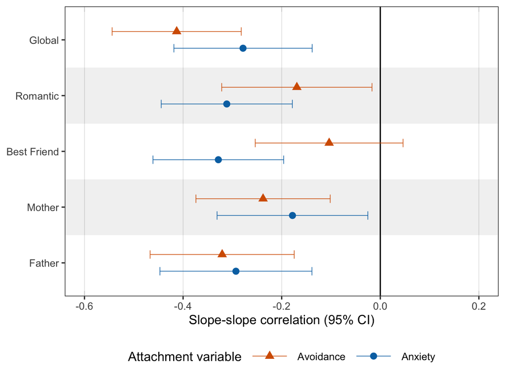

```r
plot_rq3_css_24m
```

Nothing changes in terms of significance evaluation (compared to the 30-m. model). Correlation effect sizes also highly similar.

#### 6.2.2.7 Full model results

##### 6.2.2.7.1 Avoidance: Global

Full model results for avoidance (global) (in the consistently single people):

```r
broom::tidy(get(paste0("fit_rq3_", outcomes$short[1], "_24m")), conf.int = TRUE, conf.level = 0.95) %>%
  filter(label != "") %>%
  arrange(label) %>%
  select(term = label, est = estimate, ci_lo = conf.low, ci_hi = conf.high, p_value = p.value, est_std = std.all) %>%
  knitr::kable(digits = 3)
```

| term | est | ci_lo | ci_hi | p_value | est_std |
| --- | --- | --- | --- | --- | --- |
| a0 | 2.949 | 2.891 | 3.008 | 0.000 | 4.181 |
| a1 | -0.290 | -0.362 | -0.219 | 0.000 | -0.456 |
| bia | -0.045 | -0.098 | 0.007 | 0.090 | -0.071 |
| biw | -0.017 | -0.079 | 0.045 | 0.591 | -0.022 |
| bsa | 0.027 | -0.036 | 0.090 | 0.401 | 0.047 |
| bsw | -0.018 | -0.086 | 0.051 | 0.613 | -0.028 |
| cii | -0.192 | -0.245 | -0.138 | 0.000 | -0.325 |
| cis_aw | -0.002 | -0.060 | 0.056 | 0.949 | -0.004 |
| cis_wa | -0.055 | -0.116 | 0.007 | 0.083 | -0.103 |
| cisa | -0.050 | -0.104 | 0.005 | 0.073 | -0.111 |
| cisw | -0.048 | -0.117 | 0.021 | 0.169 | -0.082 |
| css | -0.184 | -0.256 | -0.113 | 0.000 | -0.413 |
| ra00 | 0.195 | 0.168 | 0.221 | 0.000 | 0.281 |
| ra01 | 0.138 | 0.112 | 0.165 | 0.000 | 0.219 |
| ra02 | 0.113 | 0.092 | 0.133 | 0.000 | 0.187 |
| ra03 | 0.133 | 0.109 | 0.156 | 0.000 | 0.213 |
| ra04 | 0.152 | 0.125 | 0.179 | 0.000 | 0.236 |
| ra05 | 0.153 | 0.126 | 0.180 | 0.000 | 0.237 |
| ra06 | 0.151 | 0.124 | 0.178 | 0.000 | 0.232 |
| ra07 | 0.143 | 0.118 | 0.169 | 0.000 | 0.221 |
| ra08 | 0.120 | 0.097 | 0.142 | 0.000 | 0.190 |
| ra09 | 0.110 | 0.089 | 0.131 | 0.000 | 0.174 |
| ra10 | 0.140 | 0.115 | 0.165 | 0.000 | 0.209 |
| ra11 | 0.117 | 0.094 | 0.139 | 0.000 | 0.178 |
| ra12 | 0.107 | 0.085 | 0.128 | 0.000 | 0.162 |
| ra13 | 0.124 | 0.098 | 0.150 | 0.000 | 0.179 |
| ra14 | 0.100 | 0.077 | 0.123 | 0.000 | 0.146 |
| ra15 | 0.097 | 0.073 | 0.122 | 0.000 | 0.139 |
| ra16 | 0.095 | 0.070 | 0.119 | 0.000 | 0.132 |
| ra17 | 0.136 | 0.096 | 0.176 | 0.000 | 0.175 |

[output cut: 60 more lines]

##### 6.2.2.7.2 Avoidance: Romantic

Full model results for avoidance (romantic) (in the consistently single people):

```r
broom::tidy(get(paste0("fit_rq3_", outcomes$short[2], "_24m")), conf.int = TRUE, conf.level = 0.95) %>%
  filter(label != "") %>%
  arrange(label) %>%
  select(term = label, est = estimate, ci_lo = conf.low, ci_hi = conf.high, p_value = p.value, est_std = std.all) %>%
  knitr::kable(digits = 3)
```

| term | est | ci_lo | ci_hi | p_value | est_std |
| --- | --- | --- | --- | --- | --- |
| a0 | 2.309 | 2.253 | 2.366 | 0.000 | 3.462 |
| a1 | -0.181 | -0.262 | -0.100 | 0.000 | -0.256 |
| bia | 0.070 | 0.020 | 0.121 | 0.007 | 0.117 |
| biw | -0.017 | -0.079 | 0.045 | 0.587 | -0.023 |
| bsa | -0.076 | -0.146 | -0.005 | 0.036 | -0.119 |
| bsw | -0.016 | -0.085 | 0.052 | 0.640 | -0.026 |
| cii | -0.125 | -0.176 | -0.075 | 0.000 | -0.226 |
| cis_aw | -0.062 | -0.118 | -0.006 | 0.030 | -0.133 |
| cis_wa | -0.015 | -0.085 | 0.054 | 0.669 | -0.026 |
| cisa | -0.060 | -0.121 | 0.000 | 0.052 | -0.129 |
| cisw | -0.047 | -0.116 | 0.022 | 0.180 | -0.080 |
| css | -0.084 | -0.163 | -0.004 | 0.038 | -0.169 |
| ra00 | 0.335 | 0.291 | 0.378 | 0.000 | 0.429 |
| ra01 | 0.209 | 0.170 | 0.249 | 0.000 | 0.322 |
| ra02 | 0.186 | 0.153 | 0.218 | 0.000 | 0.298 |
| ra03 | 0.162 | 0.133 | 0.191 | 0.000 | 0.271 |
| ra04 | 0.167 | 0.136 | 0.197 | 0.000 | 0.276 |
| ra05 | 0.196 | 0.162 | 0.231 | 0.000 | 0.309 |
| ra06 | 0.173 | 0.141 | 0.205 | 0.000 | 0.280 |
| ra07 | 0.190 | 0.156 | 0.224 | 0.000 | 0.296 |
| ra08 | 0.157 | 0.128 | 0.186 | 0.000 | 0.255 |
| ra09 | 0.159 | 0.129 | 0.188 | 0.000 | 0.253 |
| ra10 | 0.132 | 0.107 | 0.157 | 0.000 | 0.215 |
| ra11 | 0.166 | 0.135 | 0.197 | 0.000 | 0.251 |
| ra12 | 0.152 | 0.122 | 0.182 | 0.000 | 0.230 |
| ra13 | 0.137 | 0.108 | 0.165 | 0.000 | 0.205 |
| ra14 | 0.128 | 0.099 | 0.157 | 0.000 | 0.189 |
| ra15 | 0.118 | 0.089 | 0.147 | 0.000 | 0.171 |
| ra16 | 0.122 | 0.090 | 0.153 | 0.000 | 0.170 |
| ra17 | 0.130 | 0.091 | 0.169 | 0.000 | 0.174 |

[output cut: 60 more lines]

##### 6.2.2.7.3 Avoidance: Best Friend

Full model results for avoidance (best friend) (in the consistently single people):

```r
broom::tidy(get(paste0("fit_rq3_", outcomes$short[3], "_24m")), conf.int = TRUE, conf.level = 0.95) %>%
  filter(label != "") %>%
  arrange(label) %>%
  select(term = label, est = estimate, ci_lo = conf.low, ci_hi = conf.high, p_value = p.value, est_std = std.all) %>%
  knitr::kable(digits = 3)
```

| term | est | ci_lo | ci_hi | p_value | est_std |
| --- | --- | --- | --- | --- | --- |
| a0 | 2.225 | 2.164 | 2.285 | 0.000 | 3.109 |
| a1 | 0.255 | 0.158 | 0.352 | 0.000 | 0.278 |
| bia | -0.029 | -0.083 | 0.026 | 0.300 | -0.045 |
| biw | -0.017 | -0.079 | 0.044 | 0.579 | -0.023 |
| bsa | -0.085 | -0.171 | 0.000 | 0.051 | -0.103 |
| bsw | -0.014 | -0.082 | 0.055 | 0.692 | -0.022 |
| cii | -0.204 | -0.259 | -0.149 | 0.000 | -0.341 |
| cis_aw | -0.035 | -0.094 | 0.023 | 0.236 | -0.070 |
| cis_wa | 0.005 | -0.079 | 0.089 | 0.907 | 0.007 |
| cisa | -0.108 | -0.184 | -0.031 | 0.006 | -0.165 |
| cisw | -0.046 | -0.115 | 0.022 | 0.184 | -0.079 |
| css | -0.066 | -0.164 | 0.031 | 0.180 | -0.104 |
| ra00 | 0.273 | 0.235 | 0.311 | 0.000 | 0.347 |
| ra01 | 0.193 | 0.155 | 0.230 | 0.000 | 0.276 |
| ra02 | 0.152 | 0.124 | 0.181 | 0.000 | 0.234 |
| ra03 | 0.180 | 0.148 | 0.212 | 0.000 | 0.265 |
| ra04 | 0.228 | 0.186 | 0.270 | 0.000 | 0.313 |
| ra05 | 0.193 | 0.159 | 0.228 | 0.000 | 0.276 |
| ra06 | 0.185 | 0.151 | 0.219 | 0.000 | 0.264 |
| ra07 | 0.208 | 0.171 | 0.244 | 0.000 | 0.283 |
| ra08 | 0.210 | 0.172 | 0.249 | 0.000 | 0.280 |
| ra09 | 0.173 | 0.140 | 0.206 | 0.000 | 0.236 |
| ra10 | 0.146 | 0.119 | 0.174 | 0.000 | 0.201 |
| ra11 | 0.181 | 0.146 | 0.216 | 0.000 | 0.231 |
| ra12 | 0.181 | 0.145 | 0.217 | 0.000 | 0.223 |
| ra13 | 0.117 | 0.091 | 0.142 | 0.000 | 0.150 |
| ra14 | 0.200 | 0.156 | 0.244 | 0.000 | 0.223 |
| ra15 | 0.240 | 0.185 | 0.296 | 0.000 | 0.247 |
| ra16 | 0.185 | 0.138 | 0.232 | 0.000 | 0.193 |
| ra17 | 0.174 | 0.123 | 0.225 | 0.000 | 0.176 |

[output cut: 60 more lines]

##### 6.2.2.7.4 Avoidance: Mother

Full model results for avoidance (mother) (in the consistently single people):

```r
broom::tidy(get(paste0("fit_rq3_", outcomes$short[4], "_24m")), conf.int = TRUE, conf.level = 0.95) %>%
  filter(label != "") %>%
  arrange(label) %>%
  select(term = label, est = estimate, ci_lo = conf.low, ci_hi = conf.high, p_value = p.value, est_std = std.all) %>%
  knitr::kable(digits = 3)
```

| term | est | ci_lo | ci_hi | p_value | est_std |
| --- | --- | --- | --- | --- | --- |
| a0 | 3.173 | 3.074 | 3.271 | 0.000 | 2.893 |
| a1 | -0.387 | -0.495 | -0.280 | 0.000 | -0.400 |
| bia | 0.182 | 0.078 | 0.286 | 0.001 | 0.150 |
| biw | -0.059 | -0.140 | 0.022 | 0.155 | -0.063 |
| bsa | -0.093 | -0.208 | 0.021 | 0.111 | -0.087 |
| bsw | 0.019 | -0.077 | 0.114 | 0.701 | 0.023 |
| cii | -0.280 | -0.366 | -0.195 | 0.000 | -0.309 |
| cis_aw | 0.025 | -0.070 | 0.120 | 0.603 | 0.031 |
| cis_wa | -0.013 | -0.103 | 0.078 | 0.780 | -0.016 |
| cisa | -0.286 | -0.406 | -0.167 | 0.000 | -0.274 |
| cisw | -0.067 | -0.145 | 0.010 | 0.090 | -0.108 |
| css | -0.170 | -0.276 | -0.065 | 0.002 | -0.238 |
| ra00 | 0.257 | 0.219 | 0.296 | 0.000 | 0.176 |
| ra01 | 0.166 | 0.129 | 0.202 | 0.000 | 0.123 |
| ra02 | 0.178 | 0.145 | 0.211 | 0.000 | 0.133 |
| ra03 | 0.174 | 0.140 | 0.207 | 0.000 | 0.132 |
| ra04 | 0.146 | 0.118 | 0.175 | 0.000 | 0.115 |
| ra05 | 0.176 | 0.143 | 0.210 | 0.000 | 0.136 |
| ra06 | 0.151 | 0.122 | 0.180 | 0.000 | 0.120 |
| ra07 | 0.123 | 0.099 | 0.148 | 0.000 | 0.100 |
| ra08 | 0.141 | 0.113 | 0.168 | 0.000 | 0.113 |
| ra09 | 0.120 | 0.096 | 0.144 | 0.000 | 0.098 |
| ra10 | 0.121 | 0.097 | 0.144 | 0.000 | 0.097 |
| ra11 | 0.154 | 0.124 | 0.185 | 0.000 | 0.120 |
| ra12 | 0.120 | 0.094 | 0.145 | 0.000 | 0.095 |
| ra13 | 0.089 | 0.068 | 0.111 | 0.000 | 0.071 |
| ra14 | 0.082 | 0.061 | 0.103 | 0.000 | 0.065 |
| ra15 | 0.096 | 0.070 | 0.123 | 0.000 | 0.074 |
| ra16 | 0.118 | 0.085 | 0.151 | 0.000 | 0.087 |
| ra17 | 0.085 | 0.057 | 0.114 | 0.000 | 0.063 |

[output cut: 60 more lines]

##### 6.2.2.7.5 Avoidance: Father

Full model results for avoidance (father) (in the consistently single people):

```r
broom::tidy(get(paste0("fit_rq3_", outcomes$short[5], "_24m")), conf.int = TRUE, conf.level = 0.95) %>%
  filter(label != "") %>%
  arrange(label) %>%
  select(term = label, est = estimate, ci_lo = conf.low, ci_hi = conf.high, p_value = p.value, est_std = std.all) %>%
  knitr::kable(digits = 3)
```

| term | est | ci_lo | ci_hi | p_value | est_std |
| --- | --- | --- | --- | --- | --- |
| a0 | 3.425 | 3.325 | 3.524 | 0.000 | 3.424 |
| a1 | -0.250 | -0.353 | -0.146 | 0.000 | -0.311 |
| bia | 0.031 | -0.077 | 0.139 | 0.570 | 0.027 |
| biw | -0.012 | -0.104 | 0.079 | 0.792 | -0.012 |
| bsa | 0.010 | -0.102 | 0.123 | 0.855 | 0.011 |
| bsw | 0.067 | -0.042 | 0.175 | 0.227 | 0.077 |
| cii | -0.226 | -0.308 | -0.143 | 0.000 | -0.270 |
| cis_aw | 0.057 | -0.037 | 0.150 | 0.235 | 0.078 |
| cis_wa | -0.014 | -0.096 | 0.068 | 0.735 | -0.021 |
| cisa | -0.114 | -0.213 | -0.015 | 0.024 | -0.142 |
| cisw | -0.059 | -0.140 | 0.022 | 0.152 | -0.097 |
| css | -0.187 | -0.285 | -0.090 | 0.000 | -0.321 |
| ra00 | 0.218 | 0.184 | 0.252 | 0.000 | 0.179 |
| ra01 | 0.122 | 0.094 | 0.150 | 0.000 | 0.110 |
| ra02 | 0.105 | 0.083 | 0.127 | 0.000 | 0.096 |
| ra03 | 0.154 | 0.123 | 0.185 | 0.000 | 0.136 |
| ra04 | 0.148 | 0.117 | 0.178 | 0.000 | 0.131 |
| ra05 | 0.122 | 0.097 | 0.148 | 0.000 | 0.111 |
| ra06 | 0.133 | 0.105 | 0.161 | 0.000 | 0.119 |
| ra07 | 0.172 | 0.138 | 0.207 | 0.000 | 0.148 |
| ra08 | 0.129 | 0.101 | 0.156 | 0.000 | 0.114 |
| ra09 | 0.121 | 0.095 | 0.147 | 0.000 | 0.107 |
| ra10 | 0.112 | 0.088 | 0.135 | 0.000 | 0.098 |
| ra11 | 0.122 | 0.095 | 0.149 | 0.000 | 0.105 |
| ra12 | 0.077 | 0.059 | 0.095 | 0.000 | 0.068 |
| ra13 | 0.078 | 0.058 | 0.098 | 0.000 | 0.068 |
| ra14 | 0.109 | 0.080 | 0.138 | 0.000 | 0.090 |
| ra15 | 0.093 | 0.066 | 0.121 | 0.000 | 0.077 |
| ra16 | 0.122 | 0.086 | 0.158 | 0.000 | 0.096 |
| ra17 | 0.072 | 0.045 | 0.099 | 0.000 | 0.057 |

[output cut: 60 more lines]

##### 6.2.2.7.6 Anxiety: Global

Full model results for anxiety (global) (in the consistently single people):

```r
broom::tidy(get(paste0("fit_rq3_", outcomes$short[6], "_24m")), conf.int = TRUE, conf.level = 0.95) %>%
  filter(label != "") %>%
  arrange(label) %>%
  select(term = label, est = estimate, ci_lo = conf.low, ci_hi = conf.high, p_value = p.value, est_std = std.all) %>%
  knitr::kable(digits = 3)
```

| term | est | ci_lo | ci_hi | p_value | est_std |
| --- | --- | --- | --- | --- | --- |
| a0 | 3.430 | 3.353 | 3.507 | 0.000 | 3.740 |
| a1 | -0.775 | -0.878 | -0.672 | 0.000 | -0.843 |
| bia | -0.005 | -0.074 | 0.064 | 0.880 | -0.006 |
| biw | -0.016 | -0.078 | 0.046 | 0.608 | -0.021 |
| bsa | -0.037 | -0.128 | 0.054 | 0.423 | -0.045 |
| bsw | -0.019 | -0.088 | 0.050 | 0.593 | -0.030 |
| cii | -0.321 | -0.393 | -0.249 | 0.000 | -0.417 |
| cis_aw | 0.075 | -0.001 | 0.151 | 0.053 | 0.116 |
| cis_wa | 0.001 | -0.088 | 0.090 | 0.983 | 0.001 |
| cisa | -0.130 | -0.233 | -0.026 | 0.014 | -0.154 |
| cisw | -0.050 | -0.119 | 0.019 | 0.156 | -0.085 |
| css | -0.181 | -0.281 | -0.080 | 0.000 | -0.278 |
| ra00 | 0.357 | 0.307 | 0.407 | 0.000 | 0.298 |
| ra01 | 0.279 | 0.225 | 0.332 | 0.000 | 0.251 |
| ra02 | 0.252 | 0.207 | 0.296 | 0.000 | 0.234 |
| ra03 | 0.285 | 0.235 | 0.335 | 0.000 | 0.258 |
| ra04 | 0.336 | 0.276 | 0.396 | 0.000 | 0.290 |
| ra05 | 0.327 | 0.270 | 0.384 | 0.000 | 0.284 |
| ra06 | 0.318 | 0.261 | 0.375 | 0.000 | 0.277 |
| ra07 | 0.259 | 0.212 | 0.305 | 0.000 | 0.235 |
| ra08 | 0.256 | 0.209 | 0.304 | 0.000 | 0.231 |
| ra09 | 0.246 | 0.200 | 0.293 | 0.000 | 0.221 |
| ra10 | 0.272 | 0.223 | 0.321 | 0.000 | 0.235 |
| ra11 | 0.221 | 0.178 | 0.264 | 0.000 | 0.195 |
| ra12 | 0.254 | 0.204 | 0.304 | 0.000 | 0.214 |
| ra13 | 0.269 | 0.214 | 0.324 | 0.000 | 0.218 |
| ra14 | 0.262 | 0.205 | 0.318 | 0.000 | 0.208 |
| ra15 | 0.234 | 0.176 | 0.293 | 0.000 | 0.185 |
| ra16 | 0.239 | 0.175 | 0.303 | 0.000 | 0.183 |
| ra17 | 0.217 | 0.152 | 0.283 | 0.000 | 0.164 |

[output cut: 60 more lines]

##### 6.2.2.7.7 Anxiety: Romantic

Full model results for anxiety (romantic) (in the consistently single people):

```r
broom::tidy(get(paste0("fit_rq3_", outcomes$short[7], "_24m")), conf.int = TRUE, conf.level = 0.95) %>%
  filter(label != "") %>%
  arrange(label) %>%
  select(term = label, est = estimate, ci_lo = conf.low, ci_hi = conf.high, p_value = p.value, est_std = std.all) %>%
  knitr::kable(digits = 3)
```

| term | est | ci_lo | ci_hi | p_value | est_std |
| --- | --- | --- | --- | --- | --- |
| a0 | 3.292 | 3.210 | 3.374 | 0.000 | 3.391 |
| a1 | -0.648 | -0.765 | -0.530 | 0.000 | -0.593 |
| bia | 0.010 | -0.064 | 0.083 | 0.794 | 0.011 |
| biw | -0.017 | -0.079 | 0.044 | 0.581 | -0.023 |
| bsa | -0.102 | -0.206 | 0.001 | 0.053 | -0.104 |
| bsw | -0.015 | -0.083 | 0.054 | 0.680 | -0.023 |
| cii | -0.283 | -0.358 | -0.209 | 0.000 | -0.349 |
| cis_aw | 0.064 | -0.016 | 0.144 | 0.114 | 0.094 |
| cis_wa | -0.024 | -0.125 | 0.078 | 0.648 | -0.026 |
| cisa | -0.185 | -0.308 | -0.061 | 0.003 | -0.175 |
| cisw | -0.049 | -0.119 | 0.020 | 0.163 | -0.083 |
| css | -0.239 | -0.353 | -0.125 | 0.000 | -0.311 |
| ra00 | 0.549 | 0.476 | 0.623 | 0.000 | 0.368 |
| ra01 | 0.255 | 0.203 | 0.308 | 0.000 | 0.216 |
| ra02 | 0.370 | 0.308 | 0.433 | 0.000 | 0.287 |
| ra03 | 0.293 | 0.240 | 0.345 | 0.000 | 0.242 |
| ra04 | 0.382 | 0.314 | 0.450 | 0.000 | 0.295 |
| ra05 | 0.360 | 0.297 | 0.424 | 0.000 | 0.282 |
| ra06 | 0.290 | 0.236 | 0.343 | 0.000 | 0.238 |
| ra07 | 0.384 | 0.316 | 0.451 | 0.000 | 0.290 |
| ra08 | 0.282 | 0.230 | 0.334 | 0.000 | 0.227 |
| ra09 | 0.292 | 0.238 | 0.347 | 0.000 | 0.230 |
| ra10 | 0.240 | 0.195 | 0.284 | 0.000 | 0.193 |
| ra11 | 0.218 | 0.175 | 0.261 | 0.000 | 0.174 |
| ra12 | 0.237 | 0.190 | 0.284 | 0.000 | 0.181 |
| ra13 | 0.270 | 0.215 | 0.325 | 0.000 | 0.195 |
| ra14 | 0.250 | 0.194 | 0.306 | 0.000 | 0.178 |
| ra15 | 0.239 | 0.182 | 0.297 | 0.000 | 0.165 |
| ra16 | 0.262 | 0.197 | 0.327 | 0.000 | 0.172 |
| ra17 | 0.264 | 0.186 | 0.342 | 0.000 | 0.167 |

[output cut: 60 more lines]

##### 6.2.2.7.8 Anxiety: Best Friend

Full model results for anxiety (best friend) (in the consistently single people):

```r
broom::tidy(get(paste0("fit_rq3_", outcomes$short[8], "_24m")), conf.int = TRUE, conf.level = 0.95) %>%
  filter(label != "") %>%
  arrange(label) %>%
  select(term = label, est = estimate, ci_lo = conf.low, ci_hi = conf.high, p_value = p.value, est_std = std.all) %>%
  knitr::kable(digits = 3)
```

| term | est | ci_lo | ci_hi | p_value | est_std |
| --- | --- | --- | --- | --- | --- |
| a0 | 2.330 | 2.248 | 2.412 | 0.000 | 2.379 |
| a1 | -0.185 | -0.299 | -0.071 | 0.002 | -0.171 |
| bia | 0.015 | -0.058 | 0.089 | 0.683 | 0.017 |
| biw | -0.016 | -0.078 | 0.046 | 0.608 | -0.021 |
| bsa | -0.088 | -0.189 | 0.013 | 0.088 | -0.090 |
| bsw | -0.019 | -0.088 | 0.049 | 0.578 | -0.031 |
| cii | -0.301 | -0.376 | -0.225 | 0.000 | -0.367 |
| cis_aw | 0.071 | -0.010 | 0.152 | 0.086 | 0.103 |
| cis_wa | 0.102 | 0.003 | 0.201 | 0.044 | 0.113 |
| cisa | -0.464 | -0.596 | -0.333 | 0.000 | -0.440 |
| cisw | -0.047 | -0.116 | 0.022 | 0.179 | -0.080 |
| css | -0.249 | -0.361 | -0.137 | 0.000 | -0.328 |
| ra00 | 0.479 | 0.414 | 0.544 | 0.000 | 0.333 |
| ra01 | 0.280 | 0.224 | 0.337 | 0.000 | 0.233 |
| ra02 | 0.279 | 0.230 | 0.329 | 0.000 | 0.239 |
| ra03 | 0.334 | 0.276 | 0.392 | 0.000 | 0.280 |
| ra04 | 0.289 | 0.235 | 0.343 | 0.000 | 0.257 |
| ra05 | 0.295 | 0.242 | 0.347 | 0.000 | 0.266 |
| ra06 | 0.252 | 0.205 | 0.299 | 0.000 | 0.240 |
| ra07 | 0.281 | 0.230 | 0.331 | 0.000 | 0.264 |
| ra08 | 0.295 | 0.241 | 0.348 | 0.000 | 0.275 |
| ra09 | 0.315 | 0.257 | 0.374 | 0.000 | 0.289 |
| ra10 | 0.294 | 0.240 | 0.347 | 0.000 | 0.275 |
| ra11 | 0.281 | 0.227 | 0.335 | 0.000 | 0.264 |
| ra12 | 0.190 | 0.150 | 0.230 | 0.000 | 0.193 |
| ra13 | 0.207 | 0.164 | 0.250 | 0.000 | 0.204 |
| ra14 | 0.203 | 0.157 | 0.248 | 0.000 | 0.197 |
| ra15 | 0.268 | 0.205 | 0.332 | 0.000 | 0.240 |
| ra16 | 0.238 | 0.177 | 0.299 | 0.000 | 0.213 |
| ra17 | 0.231 | 0.164 | 0.299 | 0.000 | 0.202 |

[output cut: 60 more lines]

##### 6.2.2.7.9 Anxiety: Mother

Full model results for anxiety (mother) (in the consistently single people):

```r
broom::tidy(get(paste0("fit_rq3_", outcomes$short[9], "_24m")), conf.int = TRUE, conf.level = 0.95) %>%
  filter(label != "") %>%
  arrange(label) %>%
  select(term = label, est = estimate, ci_lo = conf.low, ci_hi = conf.high, p_value = p.value, est_std = std.all) %>%
  knitr::kable(digits = 3)
```

| term | est | ci_lo | ci_hi | p_value | est_std |
| --- | --- | --- | --- | --- | --- |
| a0 | 2.059 | 1.971 | 2.147 | 0.000 | 2.095 |
| a1 | -0.265 | -0.368 | -0.163 | 0.000 | -0.314 |
| bia | 0.247 | 0.154 | 0.341 | 0.000 | 0.227 |
| biw | -0.061 | -0.142 | 0.021 | 0.144 | -0.065 |
| bsa | -0.154 | -0.262 | -0.045 | 0.005 | -0.164 |
| bsw | 0.020 | -0.075 | 0.116 | 0.678 | 0.025 |
| cii | -0.269 | -0.346 | -0.191 | 0.000 | -0.335 |
| cis_aw | 0.073 | -0.014 | 0.160 | 0.099 | 0.103 |
| cis_wa | 0.079 | -0.007 | 0.166 | 0.072 | 0.114 |
| cisa | -0.341 | -0.450 | -0.233 | 0.000 | -0.428 |
| cisw | -0.069 | -0.146 | 0.009 | 0.083 | -0.110 |
| css | -0.110 | -0.208 | -0.012 | 0.028 | -0.178 |
| ra00 | 0.410 | 0.352 | 0.467 | 0.000 | 0.298 |
| ra01 | 0.246 | 0.196 | 0.296 | 0.000 | 0.208 |
| ra02 | 0.182 | 0.147 | 0.218 | 0.000 | 0.168 |
| ra03 | 0.209 | 0.169 | 0.249 | 0.000 | 0.192 |
| ra04 | 0.232 | 0.188 | 0.276 | 0.000 | 0.213 |
| ra05 | 0.166 | 0.134 | 0.198 | 0.000 | 0.165 |
| ra06 | 0.115 | 0.091 | 0.139 | 0.000 | 0.123 |
| ra07 | 0.167 | 0.134 | 0.199 | 0.000 | 0.172 |
| ra08 | 0.170 | 0.136 | 0.204 | 0.000 | 0.176 |
| ra09 | 0.154 | 0.123 | 0.186 | 0.000 | 0.164 |
| ra10 | 0.223 | 0.181 | 0.266 | 0.000 | 0.223 |
| ra11 | 0.222 | 0.178 | 0.267 | 0.000 | 0.223 |
| ra12 | 0.131 | 0.102 | 0.160 | 0.000 | 0.145 |
| ra13 | 0.187 | 0.146 | 0.227 | 0.000 | 0.194 |
| ra14 | 0.184 | 0.141 | 0.227 | 0.000 | 0.191 |
| ra15 | 0.161 | 0.118 | 0.203 | 0.000 | 0.170 |
| ra16 | 0.128 | 0.092 | 0.163 | 0.000 | 0.138 |
| ra17 | 0.190 | 0.131 | 0.248 | 0.000 | 0.190 |

[output cut: 60 more lines]

##### 6.2.2.7.10 Anxiety: Father

Full model results for anxiety (father) (in the consistently single people):

```r
broom::tidy(get(paste0("fit_rq3_", outcomes$short[10], "_24m")), conf.int = TRUE, conf.level = 0.95) %>%
  filter(label != "") %>%
  arrange(label) %>%
  select(term = label, est = estimate, ci_lo = conf.low, ci_hi = conf.high, p_value = p.value, est_std = std.all) %>%
  knitr::kable(digits = 3)
```

| term | est | ci_lo | ci_hi | p_value | est_std |
| --- | --- | --- | --- | --- | --- |
| a0 | 2.184 | 2.087 | 2.281 | 0.000 | 2.286 |
| a1 | -0.276 | -0.395 | -0.157 | 0.000 | -0.311 |
| bia | 0.101 | -0.004 | 0.206 | 0.059 | 0.090 |
| biw | -0.011 | -0.103 | 0.080 | 0.807 | -0.012 |
| bsa | -0.223 | -0.353 | -0.093 | 0.001 | -0.212 |
| bsw | 0.058 | -0.049 | 0.166 | 0.287 | 0.068 |
| cii | -0.196 | -0.275 | -0.117 | 0.000 | -0.247 |
| cis_aw | 0.166 | 0.076 | 0.256 | 0.000 | 0.239 |
| cis_wa | -0.014 | -0.108 | 0.080 | 0.774 | -0.019 |
| cisa | -0.230 | -0.344 | -0.116 | 0.000 | -0.278 |
| cisw | -0.054 | -0.135 | 0.026 | 0.188 | -0.089 |
| css | -0.185 | -0.292 | -0.079 | 0.001 | -0.293 |
| ra00 | 0.359 | 0.304 | 0.415 | 0.000 | 0.282 |
| ra01 | 0.224 | 0.175 | 0.274 | 0.000 | 0.201 |
| ra02 | 0.234 | 0.187 | 0.281 | 0.000 | 0.211 |
| ra03 | 0.231 | 0.185 | 0.278 | 0.000 | 0.212 |
| ra04 | 0.231 | 0.182 | 0.280 | 0.000 | 0.213 |
| ra05 | 0.193 | 0.153 | 0.233 | 0.000 | 0.186 |
| ra06 | 0.153 | 0.119 | 0.186 | 0.000 | 0.154 |
| ra07 | 0.233 | 0.186 | 0.281 | 0.000 | 0.218 |
| ra08 | 0.202 | 0.159 | 0.244 | 0.000 | 0.194 |
| ra09 | 0.188 | 0.146 | 0.230 | 0.000 | 0.183 |
| ra10 | 0.219 | 0.173 | 0.264 | 0.000 | 0.205 |
| ra11 | 0.213 | 0.167 | 0.260 | 0.000 | 0.199 |
| ra12 | 0.121 | 0.092 | 0.150 | 0.000 | 0.122 |
| ra13 | 0.233 | 0.178 | 0.287 | 0.000 | 0.208 |
| ra14 | 0.229 | 0.171 | 0.287 | 0.000 | 0.202 |
| ra15 | 0.155 | 0.110 | 0.199 | 0.000 | 0.143 |
| ra16 | 0.136 | 0.095 | 0.177 | 0.000 | 0.125 |
| ra17 | 0.117 | 0.074 | 0.160 | 0.000 | 0.106 |

[output cut: 60 more lines]

# 7 Packages used

```r
pkgs <- grateful::cite_packages(output = "table", out.dir = ".")
knitr::kable(pkgs)
```

| Package | Version | Citation |
| --- | --- | --- |
| base | 4.6.0 | R Core Team (2026) |
| broom.mixed | 0.2.9.7 | Bolker & Robinson (2026) |
| corrplot | 0.95 | Wei & Simko (2024) |
| cowplot | 1.2.0 | Wilke (2025) |
| ggeffects | 2.3.2 | Lüdecke (2018) |
| ggh4x | 0.3.1 | van den Brand (2025) |
| Hmisc | 5.2.6 | Harrell Jr (2026) |
| kableExtra | 1.4.1 | Zhu (2026) |
| knitr | 1.51 | Xie (2014); Xie (2015); Xie (2025) |
| labelled | 2.16.0 | Larmarange (2025) |
| lavaan | 0.7.2 | Rosseel (2012); Rosseel et al. (2026) |
| lme4 | 2.0.6 | Bates et al. (2015) |
| lmerTest | 3.2.1 | Kuznetsova et al. (2017) |
| psych | 2.6.5 | William Revelle (2026) |
| quarto | 1.5.1 | Allaire & Dervieux (2025) |
| renv | 1.2.4 | Ushey & Wickham (2026) |
| rmarkdown | 2.31 | Xie et al. (2018); Xie et al. (2020); Allaire et al. (2026) |
| scales | 1.4.0 | Wickham et al. (2025) |
| shiny | 1.14.0 | Chang et al. (2026) |
| tidyverse | 2.0.0 | Wickham et al. (2019) |

## References

Allaire, J., & Dervieux, C. (2025). *quarto: R interface to “Quarto” markdown publishing system*. https://doi.org/10.32614/CRAN.package.quarto

Allaire, J., Xie, Y., Dervieux, C., McPherson, J., Luraschi, J., Ushey, K., Atkins, A., Wickham, H., Cheng, J., Chang, W., & Iannone, R. (2026). *rmarkdown: Dynamic documents for r*. https://github.com/rstudio/rmarkdown

Bates, D., Mächler, M., Bolker, B., & Walker, S. (2015). Fitting linear mixed-effects models using lme4. *Journal of Statistical Software*, *67*(1), 1–48. https://doi.org/10.18637/jss.v067.i01

Bolker, B., & Robinson, D. (2026). *broom.mixed: Tidying methods for mixed models*. https://doi.org/10.32614/CRAN.package.broom.mixed

Chang, W., Cheng, J., Allaire, J., Sievert, C., Schloerke, B., Aden-Buie, G., Xie, Y., Allen, J., McPherson, J., Dipert, A., & Borges, B. (2026). *shiny: Web application framework for r*. https://doi.org/10.32614/CRAN.package.shiny

Harrell Jr, F. E. (2026). *Hmisc: Harrell miscellaneous*. https://doi.org/10.32614/CRAN.package.Hmisc

Kuznetsova, A., Brockhoff, P. B., & Christensen, R. H. B. (2017). lmerTest package: Tests in linear mixed effects models. *Journal of Statistical Software*, *82*(13), 1–26. https://doi.org/10.18637/jss.v082.i13

Larmarange, J. (2025). *labelled: Manipulating labelled data*. https://doi.org/10.32614/CRAN.package.labelled

Lüdecke, D. (2018). ggeffects: Tidy data frames of marginal effects from regression models. *Journal of Open Source Software*, *3*(26), 772. https://doi.org/10.21105/joss.00772

R Core Team. (2026). *R: A language and environment for statistical computing*. R Foundation for Statistical Computing. https://doi.org/10.32614/R.manuals

Rosseel, Y. (2012). lavaan: An R package for structural equation modeling. *Journal of Statistical Software*, *48*(2), 1–36. https://doi.org/10.18637/jss.v048.i02

Rosseel, Y., Jorgensen, T. D., & De Wilde, L. (2026). *lavaan: Latent variable analysis*. https://doi.org/10.32614/CRAN.package.lavaan

Ushey, K., & Wickham, H. (2026). *renv: Project environments*. https://doi.org/10.32614/CRAN.package.renv

van den Brand, T. (2025). *ggh4x: Hacks for “ggplot2”*. https://doi.org/10.32614/CRAN.package.ggh4x

Wei, T., & Simko, V. (2024). *R package “corrplot”: Visualization of a correlation matrix*. https://github.com/taiyun/corrplot

Wickham, H., Averick, M., Bryan, J., Chang, W., McGowan, L. D., François, R., Grolemund, G., Hayes, A., Henry, L., Hester, J., Kuhn, M., Pedersen, T. L., Miller, E., Bache, S. M., Müller, K., Ooms, J., Robinson, D., Seidel, D. P., Spinu, V., … Yutani, H. (2019). Welcome to the tidyverse. *Journal of Open Source Software*, *4*(43), 1686. https://doi.org/10.21105/joss.01686

Wickham, H., Pedersen, T. L., & Seidel, D. (2025). *scales: Scale functions for visualization*. https://doi.org/10.32614/CRAN.package.scales

Wilke, C. O. (2025). *cowplot: Streamlined plot theme and plot annotations for “ggplot2”*. https://doi.org/10.32614/CRAN.package.cowplot

William Revelle. (2026). *psych: Procedures for psychological, psychometric, and personality research*. Northwestern University. https://CRAN.R-project.org/package=psych

Xie, Y. (2014). knitr: A comprehensive tool for reproducible research in R. In V. Stodden, F. Leisch, & R. D. Peng (Eds.), *Implementing reproducible computational research*. Chapman; Hall/CRC.

Xie, Y. (2015). *Dynamic documents with R and knitr* (2nd ed.). Chapman; Hall/CRC. https://yihui.org/knitr/

Xie, Y. (2025). *knitr: A general-purpose package for dynamic report generation in R*. https://yihui.org/knitr/

Xie, Y., Allaire, J. J., & Grolemund, G. (2018). *R markdown: The definitive guide*. Chapman; Hall/CRC. https://yihui.org/rmarkdown/

Xie, Y., Dervieux, C., & Riederer, E. (2020). *R markdown cookbook*. Chapman; Hall/CRC. https://yihui.org/rmarkdown-cookbook

Zhu, H. (2026). *kableExtra: Construct complex table with “kable” and pipe syntax*. https://doi.org/10.32614/CRAN.package.kableExtra